# **Importación de librerias**

```python
import pandas as pd
import numpy as np
import seaborn as sns
from matplotlib import pyplot as plt
import plotly.express as px
from sklearn.impute import KNNImputer
import scipy.stats as ss
import warnings
import funciones_auxiliares as f_aux # Se crea un archivo .py desde donde importamos las funciones que vamos a utilizar

pd.set_option('display.max_columns', 500)
pd.set_option('display.max_rows', 5000)

seed = 123
```

# **Lectura del dataset**

```python
pd_loan = pd.read_csv("./pd_data_initial_preprocessing.csv")
pd_loan.head()
```

|  | SK_ID_CURR | COMMONAREA_AVG | COMMONAREA_MODE | COMMONAREA_MEDI | NONLIVINGAPARTMENTS_AVG | NONLIVINGAPARTMENTS_MODE | NONLIVINGAPARTMENTS_MEDI | FONDKAPREMONT_MODE | LIVINGAPARTMENTS_MEDI | LIVINGAPARTMENTS_AVG | LIVINGAPARTMENTS_MODE | FLOORSMIN_AVG | FLOORSMIN_MODE | FLOORSMIN_MEDI | YEARS_BUILD_AVG | YEARS_BUILD_MEDI | YEARS_BUILD_MODE | OWN_CAR_AGE | LANDAREA_MEDI | LANDAREA_AVG | LANDAREA_MODE | BASEMENTAREA_MEDI | BASEMENTAREA_AVG | BASEMENTAREA_MODE | EXT_SOURCE_1 | NONLIVINGAREA_AVG | NONLIVINGAREA_MODE | NONLIVINGAREA_MEDI | ELEVATORS_MODE | … |
| --- | --- | --- | --- | --- | --- | --- | --- | --- | --- | --- | --- | --- | --- | --- | --- | --- | --- | --- | --- | --- | --- | --- | --- | --- | --- | --- | --- | --- | --- | --- |
| 0 | 100002 | 0.0143 | 0.0144 | 0.0144 | 0.0000 | 0.0 | 0.0000 | reg oper account | 0.0205 | 0.0202 | 0.022 | 0.1250 | 0.1250 | 0.1250 | 0.6192 | 0.6243 | 0.6341 | NaN | 0.0375 | 0.0369 | 0.0377 | 0.0369 | 0.0369 | 0.0383 | 0.083037 | 0.0000 | 0.0 | 0.00 | 0.0000 | … |
| 1 | 100003 | 0.0605 | 0.0497 | 0.0608 | 0.0039 | 0.0 | 0.0039 | reg oper account | 0.0787 | 0.0773 | 0.079 | 0.3333 | 0.3333 | 0.3333 | 0.7960 | 0.7987 | 0.8040 | NaN | 0.0132 | 0.0130 | 0.0128 | 0.0529 | 0.0529 | 0.0538 | 0.311267 | 0.0098 | 0.0 | 0.01 | 0.0806 | … |
| 2 | 100004 | NaN | NaN | NaN | NaN | NaN | NaN | NaN | NaN | NaN | NaN | NaN | NaN | NaN | NaN | NaN | NaN | 26.0 | NaN | NaN | NaN | NaN | NaN | NaN | NaN | NaN | NaN | NaN | NaN | … |
| 3 | 100006 | NaN | NaN | NaN | NaN | NaN | NaN | NaN | NaN | NaN | NaN | NaN | NaN | NaN | NaN | NaN | NaN | NaN | NaN | NaN | NaN | NaN | NaN | NaN | NaN | NaN | NaN | NaN | NaN | … |
| 4 | 100007 | NaN | NaN | NaN | NaN | NaN | NaN | NaN | NaN | NaN | NaN | NaN | NaN | NaN | NaN | NaN | NaN | NaN | NaN | NaN | NaN | NaN | NaN | NaN | NaN | NaN | NaN | NaN | NaN | … |

## **Dimensión**

```python
pd_loan.shape
```

```
(307511, 122)
```

```python
list_var_cat, other = f_aux.dame_variables_categoricas(dataset=pd_loan)
pd_loan[list_var_cat] = pd_loan[list_var_cat].astype("category")
list_var_continuous = list(pd_loan.select_dtypes('float').columns)
pd_loan[list_var_continuous] = pd_loan[list_var_continuous].astype(float)
pd_loan.dtypes
```

```
SK_ID_CURR                         int64
COMMONAREA_AVG                   float64
COMMONAREA_MODE                  float64
COMMONAREA_MEDI                  float64
NONLIVINGAPARTMENTS_AVG          float64
NONLIVINGAPARTMENTS_MODE         float64
NONLIVINGAPARTMENTS_MEDI         float64
FONDKAPREMONT_MODE              category
LIVINGAPARTMENTS_MEDI            float64
LIVINGAPARTMENTS_AVG             float64
LIVINGAPARTMENTS_MODE            float64
FLOORSMIN_AVG                    float64
FLOORSMIN_MODE                  category
FLOORSMIN_MEDI                  category
YEARS_BUILD_AVG                  float64
YEARS_BUILD_MEDI                 float64
YEARS_BUILD_MODE                 float64
OWN_CAR_AGE                      float64
LANDAREA_MEDI                    float64
LANDAREA_AVG                     float64
LANDAREA_MODE                    float64
BASEMENTAREA_MEDI                float64
BASEMENTAREA_AVG                 float64
BASEMENTAREA_MODE                float64
EXT_SOURCE_1                     float64
NONLIVINGAREA_AVG                float64
NONLIVINGAREA_MODE               float64
NONLIVINGAREA_MEDI               float64
ELEVATORS_MODE                  category
ELEVATORS_AVG                    float64
ELEVATORS_MEDI                  category
WALLSMATERIAL_MODE              category
APARTMENTS_AVG                   float64
APARTMENTS_MEDI                  float64
APARTMENTS_MODE                  float64
ENTRANCES_AVG                    float64
ENTRANCES_MEDI                  category
ENTRANCES_MODE                  category
LIVINGAREA_MEDI                  float64
LIVINGAREA_MODE                  float64
```

[output cut: 68 more lines]

```
FLAG_PHONE                      category
FLAG_CONT_MOBILE                category
FLAG_WORK_PHONE                 category
FLAG_EMP_PHONE                  category
FLAG_MOBIL                      category
DAYS_ID_PUBLISH                    int64
DAYS_REGISTRATION                float64
DAYS_EMPLOYED                      int64
DAYS_BIRTH                         int64
REGION_POPULATION_RELATIVE       float64
NAME_HOUSING_TYPE               category
NAME_FAMILY_STATUS              category
NAME_EDUCATION_TYPE             category
TARGET                          category
dtype: object
```

## **Separación en train y test**

```python
pd_plot_target = pd_loan['TARGET']\
        .value_counts(normalize=True)\
        .mul(100).rename('percent').reset_index()

pd_plot_target_conteo = pd_loan['TARGET'].value_counts().reset_index()
pd_plot_target_pc = pd.merge(pd_plot_target, pd_plot_target_conteo, on=['TARGET'], how='inner')

fig = px.bar(pd_plot_target_pc, x="TARGET", y='percent', text='percent', labels={"TARGET": "Estado de Pago (TARGET)", "percent": "Porcentaje"})
fig.show()
```

[output not shown]

```python
from sklearn.model_selection import train_test_split
X_pd_loan, X_pd_loan_test, y_pd_loan, y_pd_loan_test = train_test_split(pd_loan.drop('TARGET',axis=1),
                                                                     pd_loan['TARGET'],
                                                                     stratify=pd_loan['TARGET'],
                                                                     test_size=0.2)
pd_loan_train = pd.concat([X_pd_loan, y_pd_loan],axis=1)
pd_loan_test = pd.concat([X_pd_loan_test, y_pd_loan_test],axis=1)
```

```python
print('== Train\n', pd_loan_train['TARGET'].value_counts(normalize=True))
print('== Test\n', pd_loan_test['TARGET'].value_counts(normalize=True))
```

```
== Train
 TARGET
0    0.919271
1    0.080729
Name: proportion, dtype: float64
== Test
 TARGET
0    0.919272
1    0.080728
Name: proportion, dtype: float64
```

En nuestro caso, los datos presentan una distribución desbalanceada entre las clases: el 92% pertenece a una clase y el 8% a la otra. Al utilizar el argumento stratify en la función train_test_split, aseguramos que ambos conjuntos (entrenamiento y prueba) mantengan estas proporciones originales. Esto es fundamental para garantizar que los conjuntos sean representativos de la distribución real de los datos y para evitar que el modelo entrene o se evalúe con datos sesgados.

Por ejemplo, sin estratificación, el conjunto de prueba podría contener únicamente datos de la clase mayoritaria (92%), dejando a la clase minoritaria (8%) sin representación. Esto impactaría negativamente tanto en el entrenamiento como en la evaluación del modelo, ya que no reflejaría la realidad del problema.

Gracias a stratify, las proporciones de las clases (92% y 8%) se conservan en ambos conjuntos, lo que permite realizar un análisis más confiable y representativo de los resultados.

# **Visualización descriptiva de los datos**

Se realiza la visualización de la proporción de valores nulos en columnas y filas.

```python
pd_series_null_columns = pd_loan_train.isnull().sum().sort_values(ascending=False)
pd_series_null_rows = pd_loan_train.isnull().sum(axis=1).sort_values(ascending=False)
print(pd_series_null_columns.shape, pd_series_null_rows.shape)

pd_null_columnas = pd.DataFrame(pd_series_null_columns, columns=['nulos_columnas'])
pd_null_filas = pd.DataFrame(pd_series_null_rows, columns=['nulos_filas'])
pd_null_filas['target'] = pd_loan['TARGET'].copy()
pd_null_columnas['porcentaje_columnas'] = pd_null_columnas['nulos_columnas']/pd_loan_train.shape[0]
pd_null_filas['porcentaje_filas']= pd_null_filas['nulos_filas']/pd_loan_train.shape[1]
```

```
(122,) (246008,)
```

```python
pd_null_columnas
```

|  | nulos_columnas | porcentaje_columnas |
| --- | --- | --- |
| COMMONAREA_AVG | 171853 | 0.698567 |
| COMMONAREA_MODE | 171853 | 0.698567 |
| COMMONAREA_MEDI | 171853 | 0.698567 |
| NONLIVINGAPARTMENTS_AVG | 170767 | 0.694152 |
| NONLIVINGAPARTMENTS_MODE | 170767 | 0.694152 |
| NONLIVINGAPARTMENTS_MEDI | 170767 | 0.694152 |
| FONDKAPREMONT_MODE | 168224 | 0.683815 |
| LIVINGAPARTMENTS_MEDI | 168129 | 0.683429 |
| LIVINGAPARTMENTS_AVG | 168129 | 0.683429 |
| LIVINGAPARTMENTS_MODE | 168129 | 0.683429 |
| FLOORSMIN_AVG | 166905 | 0.678454 |
| FLOORSMIN_MODE | 166905 | 0.678454 |
| FLOORSMIN_MEDI | 166905 | 0.678454 |
| YEARS_BUILD_MEDI | 163604 | 0.665035 |
| YEARS_BUILD_MODE | 163604 | 0.665035 |
| YEARS_BUILD_AVG | 163604 | 0.665035 |
| OWN_CAR_AGE | 162380 | 0.660060 |
| LANDAREA_MEDI | 146070 | 0.593761 |
| LANDAREA_AVG | 146070 | 0.593761 |
| LANDAREA_MODE | 146070 | 0.593761 |
| BASEMENTAREA_MEDI | 143966 | 0.585209 |
| BASEMENTAREA_AVG | 143966 | 0.585209 |
| BASEMENTAREA_MODE | 143966 | 0.585209 |
| EXT_SOURCE_1 | 138919 | 0.564693 |
| NONLIVINGAREA_AVG | 135743 | 0.551783 |
| NONLIVINGAREA_MODE | 135743 | 0.551783 |
| NONLIVINGAREA_MEDI | 135743 | 0.551783 |
| ELEVATORS_AVG | 131045 | 0.532686 |
| ELEVATORS_MEDI | 131045 | 0.532686 |
| ELEVATORS_MODE | 131045 | 0.532686 |

[output cut: 92 more lines]

```python
pd_null_filas.head()
```

|  | nulos_filas | target | porcentaje_filas |
| --- | --- | --- | --- |
| 244833 | 61 | 0 | 0.5 |
| 269786 | 61 | 0 | 0.5 |
| 185713 | 61 | 0 | 0.5 |
| 116937 | 61 | 0 | 0.5 |
| 269492 | 61 | 0 | 0.5 |

# **Distribución del resto de variables**

Se decide plotear únicamente determinadas variables que son enumeradas a continuación de manera que se facilite un análisis más eficiente y dirigido a encontrar patrones relevantes y útiles a la hora de la toma de decisiones. Con esta selección busco reducir la complejidad pues el dataset contiene 121 variables pero no todas son igual de relevantes. A continuación se muestran las variables elegidas y la razón de su selección:

## Categóricas

**CODE_GENDER**: género del cliente (M/F). **Razón**: puede correlacionarse con diferencias de comportamiento crediticio.

**FLAG_OWN_CAR**: indica si el cliente posee un automóvil (1=Sí, 0=No). **Razón**: poseer un auto puede reflejar estabilidad financiera o por el contrario, gastos debido a su mantenimiento/reparación de averías.

**FLAG_OWN_REALTY**: indica si el cliente posee una casa o apartamento (1=Sí, 0=No). **Razón**: la propiedad puede usarse como garantía y refleja estabilidad.

**NAME_CONTRACT_TYPE**: tipo de contrato del préstamo (Cash loan o Revolving loan). **Razón**: diferentes tipos de contratos tienen perfiles de riesgo distintos.

**NAME_EDUCATION_TYPE**: nivel educativo alcanzado por el cliente. **Razón**: el nivel educativo está relacionado con ingresos y estabilidad laboral.

**NAME_INCOME_TYPE**: tipo de fuente de ingresos del cliente (Ej.: Empleado, Pensionado). Razón: la fuente de ingresos determina la estabilidad y capacidad de pago.

**NAME_HOUSING_TYPE**: tipo de vivienda donde reside el cliente (Ej.: Rentado, Propio). **Razón**: la situación de vivienda puede influir en el riesgo crediticio.

**REGION_RATING_CLIENT**: puntuación de la región donde vive el cliente (1, 2, 3). **Razón**: las regiones más desarrolladas tienen menores riesgos asociados.

**FLAG_WORK_PHONE**: indica si el cliente proporcionó un teléfono de trabajo (1=Sí, 0=No). **Razón**: ayuda a verificar la información laboral del cliente.

**FLAG_EMAIL**: indica si el cliente proporcionó un correo electrónico (1=Sí, 0=No). **Razón**: la disponibilidad de correo refleja acceso a servicios básicos.

## Continuas

**AMT_INCOME_TOTAL**: ingresos totales declarados por el cliente. **Razón**: los ingresos determinan la capacidad de pago.

**AMT_CREDIT**: monto del crédito solicitado por el cliente. **Razón**: la cantidad del préstamo es un factor directo del riesgo.

**AMT_ANNUITY**: monto de la anualidad correspondiente al préstamo. **Razón**: representa el compromiso financiero recurrente.

**REGION_POPULATION_RELATIVE**: población relativa de la región donde vive el cliente. **Razón**: regiones más densas pueden correlacionarse con oportunidades económicas.

**DAYS_BIRTH**: edad del cliente expresada en días. **Razón**: la edad puede reflejar experiencia financiera y estabilidad.

**DAYS_EMPLOYED**: días desde que el cliente empezó su empleo actual. **Razón**: historial laboral es un indicador de estabilidad financiera.

**EXT_SOURCE_1**: score externo normalizado para evaluar el riesgo del cliente. **Razón**: predictor externo del riesgo crediticio.

**EXT_SOURCE_2**: otro score externo normalizado para evaluar el riesgo. **Razón**: complementa la evaluación del riesgo crediticio.

**EXT_SOURCE_3**: tercer score externo normalizado. **Razón**: añade precisión a la estimación del riesgo.

**CNT_CHILDREN**: número de hijos que tiene el cliente. **Razón**: afecta los gastos y, por lo tanto, la capacidad de pago.

```python
relevant_vars = [
    'CODE_GENDER',
    'FLAG_OWN_CAR',
    'FLAG_OWN_REALTY',
    'NAME_CONTRACT_TYPE',
    'NAME_EDUCATION_TYPE',
    'NAME_INCOME_TYPE',
    'NAME_HOUSING_TYPE',
    'REGION_RATING_CLIENT',
    'FLAG_WORK_PHONE',
    'FLAG_EMAIL',
    'AMT_INCOME_TOTAL',
    'AMT_CREDIT',
    'AMT_ANNUITY',
    'REGION_POPULATION_RELATIVE',
    'DAYS_BIRTH',
    'DAYS_EMPLOYED',
    'EXT_SOURCE_1',
    'EXT_SOURCE_2',
    'EXT_SOURCE_3',
    'CNT_CHILDREN'
]
```

```python
help(f_aux.plot_feature) # Echamos un ojo a la ayuda de la función para recordar qué parametros hay que introducir y qué outputs nos devuelve
```

```
Help on function plot_feature in module funciones_auxiliares:

plot_feature(df, col_name, is_continuous, target, figsize=(12, 6), color='#5975A4')
    Visualiza una variable categórica o continua con y sin segmentación por una variable objetivo (target).

    Parámetros:
    df: dataFrame que contiene los datos.
    col_name: nombre de la columna a graficar.
    is_continuous: booleano. True si la variable es continua, False si es discreta.
    target: nombre de la variable objetivo para segmentar los datos.
    figsize: tamaño de la figura (opcional, por defecto (12, 6)).
    color: color principal de los gráficos (opcional).

    Outputs:
    Muestra los gráficos
```

[output not shown]

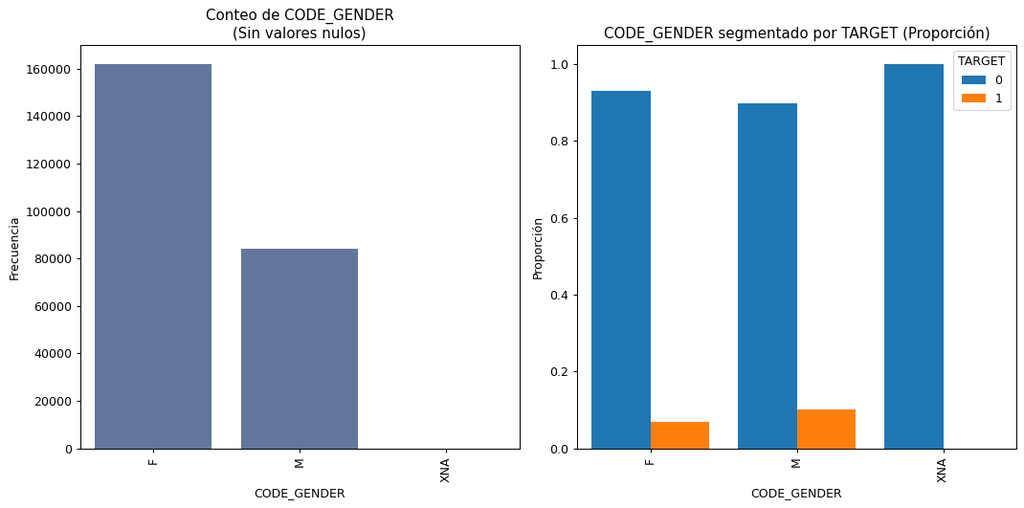

[output not shown]

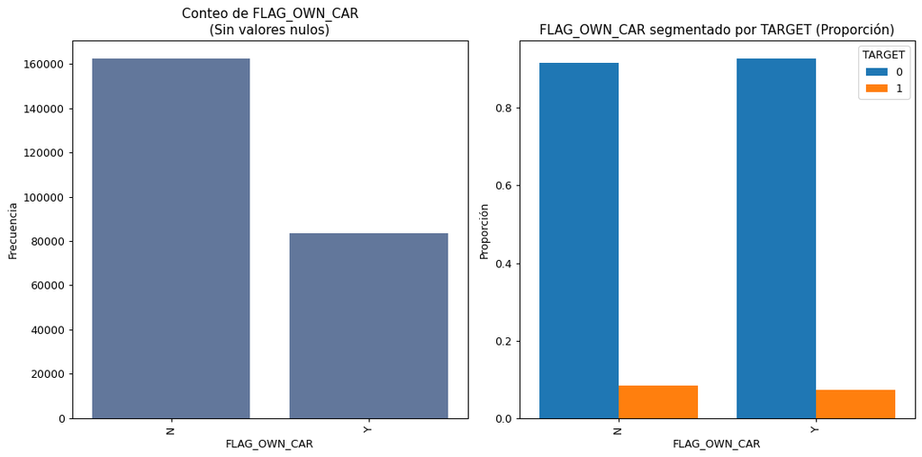

[output not shown]

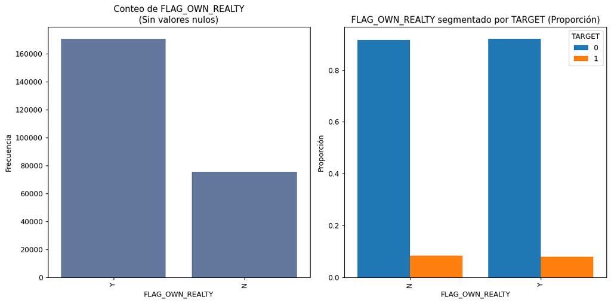

[output not shown]

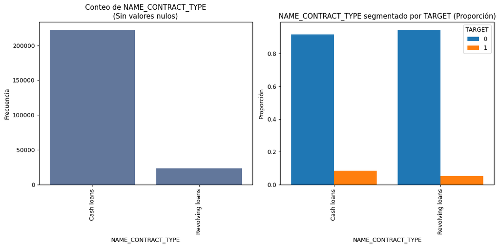

[output not shown]

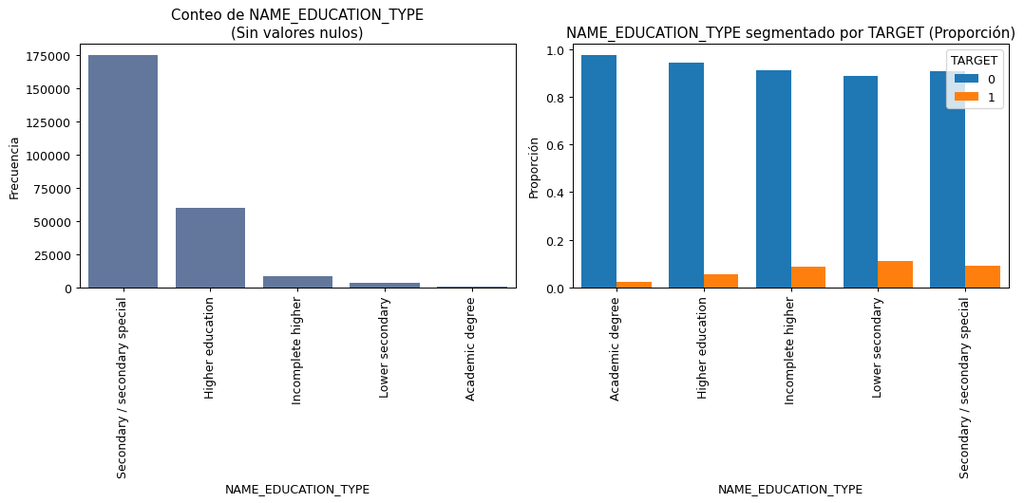

[output not shown]

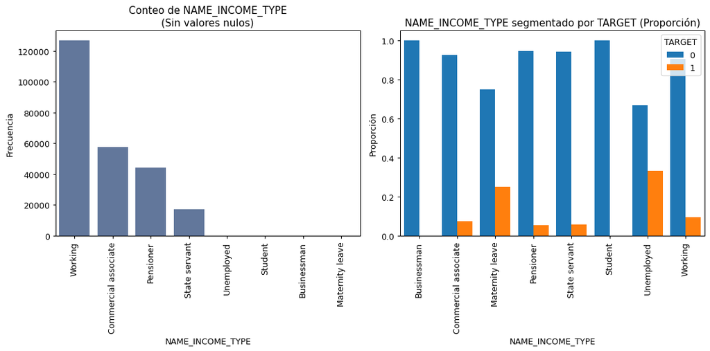

[output not shown]

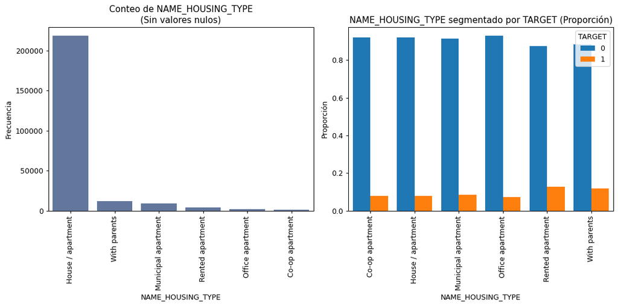

[output not shown]

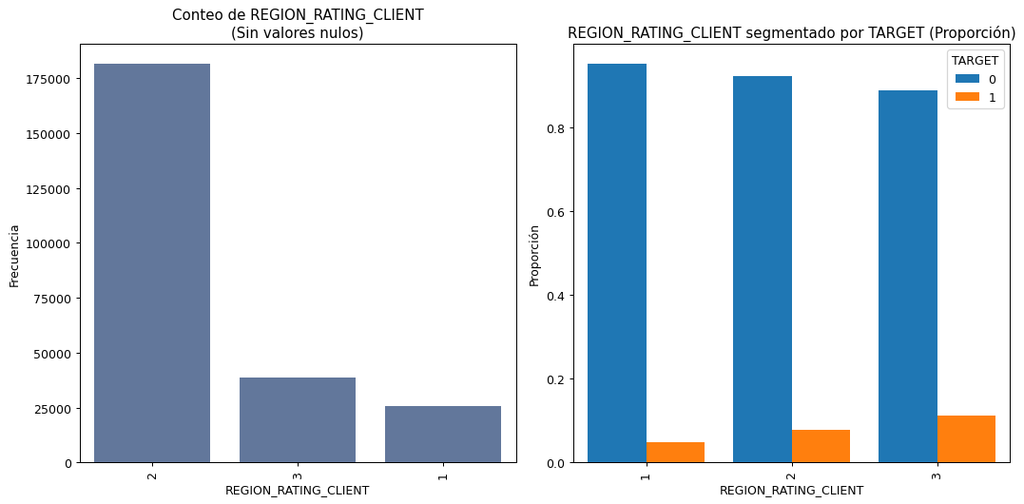

[output not shown]

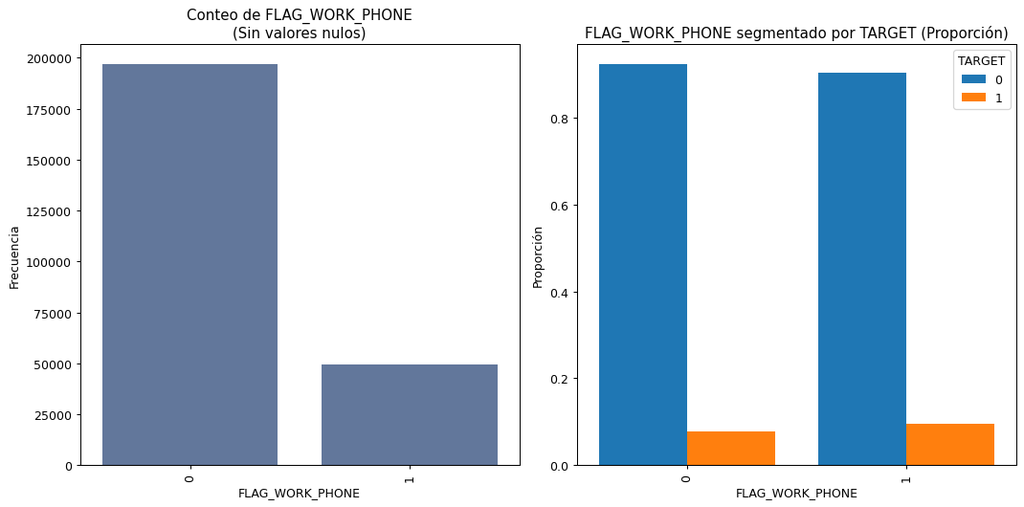

[output not shown]

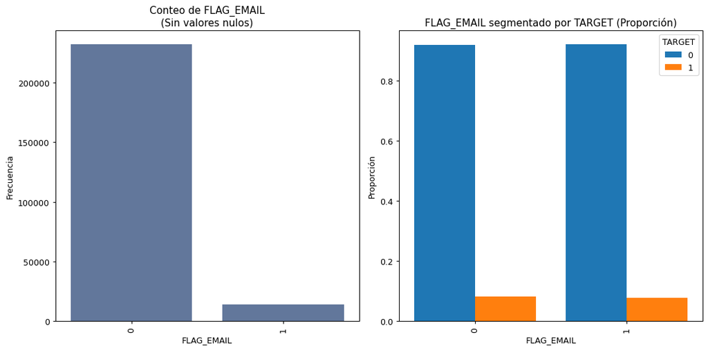

[figure not shown]

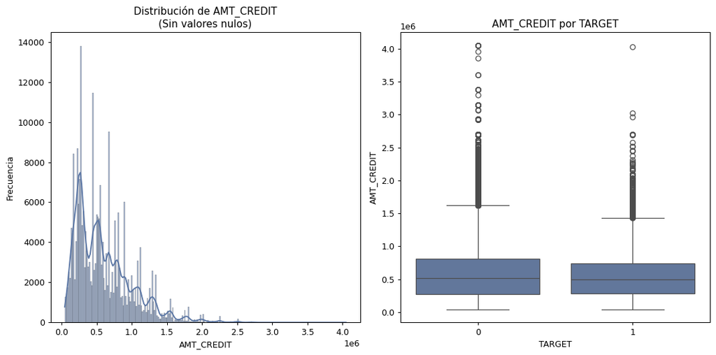

[8 more figures not shown]

```python
for i in relevant_vars:
    if (pd_loan_train[i].dtype == float) and (i != 'TARGET'):
        # Variable continua
        f_aux.plot_feature(col_name=i, is_continuous=True, df=pd_loan_train, target='TARGET')
    elif i != 'TARGET':
        # Variable discreta
        f_aux.plot_feature(col_name=i, is_continuous=False, df=pd_loan_train, target='TARGET')
```

## **Análisis de los gráficos**

### Categóricas

**2. FLAG_OWN_CAR:** existe un mayor número de clientes que no tienen auto propio y la proporción de incumplimiento es similar para quienes poseen auto y no.

**3.FLAG_OWN_REALTY:** una mayor parte de los clientes poseen bienes inmuebles. La proporción es similar.

**4.NAME_CONTRACT_TYPE:** la mayoría de los préstamos son "Cash loans" e igualmente la proporción de incumplimiento es similar entre los dos tipos de contrato

**5.NAME_EDUCATION_TYPE:** la mayoría de los clientes tienen como máxima educación secundaria ("Secondary") y se muestra una proporción algo mayor de incumplimiento en el pago para el grupo de "Lower secondary".

**6.NAME_INCOME_TYPE:** los clientes más comunes son trabajadores y comerciales asociados. Los clientes que se encuentran desempleados muestran una mayor proporción de incumplimiento.

**7.NAME_HOUSING_TYPE:** la mayoría de clientes viven en apartamentos. Las proporciones son similares entre los tipos de vivienda.

**9.FLAG_WORK_PHONE:** la mayoría de clientes no tienen un teléfono de trabajo. La proporción es similar entre quienes tienen y no movil de trabajo.

**10.FLAG_EMAIL:** la mayoría de clientes no tiene email registrado. La proporción de incumplimiento es similar

### Continuas

**1. AMT_INCOME_TOTAL:** la mayoría de ingresos están en niveles bajos con valores atípicos muy altos.

**2. AMT_CREDIT:** la distribución es sesgada hacia montos más bajos, con pocos créditos grandes.

**3. AMT_ANNUITY:** se concentran en valores bajos con algunos valores atípicos.

**4. REGION_POPULATION_RELATIVE:** la mayoría de clientes provienen de regiones menos densas.

**5. DAYS_BIRTH:** clientes más jóvenes muestran una mayor proporción de incumplimiento.

**6. EXT_SOURCE_1, 2 Y 3:** estas variables muestran una separación entre TARGET = 1 y TARGET = 0, los valores más altos están asociados con menos riesgo de incumplimiento.

# **Tratamiento de variables continuas**

```python
list_var_continuous
```

```
['COMMONAREA_AVG',
 'COMMONAREA_MODE',
 'COMMONAREA_MEDI',
 'NONLIVINGAPARTMENTS_AVG',
 'NONLIVINGAPARTMENTS_MODE',
 'NONLIVINGAPARTMENTS_MEDI',
 'LIVINGAPARTMENTS_MEDI',
 'LIVINGAPARTMENTS_AVG',
 'LIVINGAPARTMENTS_MODE',
 'FLOORSMIN_AVG',
 'YEARS_BUILD_AVG',
 'YEARS_BUILD_MEDI',
 'YEARS_BUILD_MODE',
 'OWN_CAR_AGE',
 'LANDAREA_MEDI',
 'LANDAREA_AVG',
 'LANDAREA_MODE',
 'BASEMENTAREA_MEDI',
 'BASEMENTAREA_AVG',
 'BASEMENTAREA_MODE',
 'EXT_SOURCE_1',
 'NONLIVINGAREA_AVG',
 'NONLIVINGAREA_MODE',
 'NONLIVINGAREA_MEDI',
 'ELEVATORS_AVG',
 'APARTMENTS_AVG',
 'APARTMENTS_MEDI',
 'APARTMENTS_MODE',
 'ENTRANCES_AVG',
 'LIVINGAREA_MEDI',
 'LIVINGAREA_MODE',
 'LIVINGAREA_AVG',
 'FLOORSMAX_AVG',
 'YEARS_BEGINEXPLUATATION_MEDI',
 'YEARS_BEGINEXPLUATATION_MODE',
 'YEARS_BEGINEXPLUATATION_AVG',
 'TOTALAREA_MODE',
 'EXT_SOURCE_3',
 'EXT_SOURCE_2',
 'AMT_GOODS_PRICE',
 'AMT_ANNUITY',
 'DAYS_LAST_PHONE_CHANGE',
 'AMT_INCOME_TOTAL',
 'AMT_CREDIT',
 'DAYS_REGISTRATION',
 'REGION_POPULATION_RELATIVE']
```

## Tratamiento de outliers

```python
help(f_aux.get_deviation_of_mean_perc)
```

```
Help on function get_deviation_of_mean_perc in module funciones_auxiliares:

get_deviation_of_mean_perc(pd_loan, list_var_continuous, target, multiplier)
    Devuelve el porcentaje de valores que exceden del intervalo de confianza
    :type series:
    :param multiplier:
    :return:
```

```python
f_aux.get_deviation_of_mean_perc(pd_loan_train, list_var_continuous, target='TARGET', multiplier=3)
```

|  | 0.0 | 1.0 | variable | sum_outlier_values | porcentaje_sum_null_values |
| --- | --- | --- | --- | --- | --- |
| 0 | 0.945347 | 0.054653 | COMMONAREA_AVG | 1354 | 0.005504 |
| 1 | 0.941748 | 0.058252 | COMMONAREA_MODE | 1339 | 0.005443 |
| 2 | 0.943918 | 0.056082 | COMMONAREA_MEDI | 1373 | 0.005581 |
| 3 | 0.931459 | 0.068541 | NONLIVINGAPARTMENTS_AVG | 569 | 0.002313 |
| 4 | 0.926829 | 0.073171 | NONLIVINGAPARTMENTS_MODE | 533 | 0.002167 |
| 5 | 0.932743 | 0.067257 | NONLIVINGAPARTMENTS_MEDI | 565 | 0.002297 |
| 6 | 0.947592 | 0.052408 | LIVINGAPARTMENTS_MEDI | 1412 | 0.005740 |
| 7 | 0.948791 | 0.051209 | LIVINGAPARTMENTS_AVG | 1406 | 0.005715 |
| 8 | 0.945442 | 0.054558 | LIVINGAPARTMENTS_MODE | 1448 | 0.005886 |
| 9 | 0.961039 | 0.038961 | FLOORSMIN_AVG | 462 | 0.001878 |
| 10 | 0.918776 | 0.081224 | YEARS_BUILD_AVG | 948 | 0.003854 |
| 11 | 0.919624 | 0.080376 | YEARS_BUILD_MEDI | 958 | 0.003894 |
| 12 | 0.919287 | 0.080713 | YEARS_BUILD_MODE | 954 | 0.003878 |
| 13 | 0.917695 | 0.082305 | OWN_CAR_AGE | 2673 | 0.010866 |
| 14 | 0.935446 | 0.064554 | LANDAREA_MEDI | 1704 | 0.006927 |
| 15 | 0.933333 | 0.066667 | LANDAREA_AVG | 1665 | 0.006768 |
| 16 | 0.933333 | 0.066667 | LANDAREA_MODE | 1710 | 0.006951 |
| 17 | 0.945431 | 0.054569 | BASEMENTAREA_MEDI | 1576 | 0.006406 |
| 18 | 0.946292 | 0.053708 | BASEMENTAREA_AVG | 1564 | 0.006358 |
| 19 | 0.942840 | 0.057160 | BASEMENTAREA_MODE | 1627 | 0.006614 |
| 20 | 0.954876 | 0.045124 | NONLIVINGAREA_AVG | 1928 | 0.007837 |
| 21 | 0.955056 | 0.044944 | NONLIVINGAREA_MODE | 1958 | 0.007959 |
| 22 | 0.953988 | 0.046012 | NONLIVINGAREA_MEDI | 1956 | 0.007951 |
| 23 | 0.954147 | 0.045853 | ELEVATORS_AVG | 1941 | 0.007890 |
| 24 | 0.948997 | 0.051003 | APARTMENTS_AVG | 2392 | 0.009723 |
| 25 | 0.947780 | 0.052220 | APARTMENTS_MEDI | 2432 | 0.009886 |
| 26 | 0.947368 | 0.052632 | APARTMENTS_MODE | 2432 | 0.009886 |
| 27 | 0.934091 | 0.065909 | ENTRANCES_AVG | 1760 | 0.007154 |
| 28 | 0.946981 | 0.053019 | LIVINGAREA_MEDI | 2584 | 0.010504 |
| 29 | 0.945043 | 0.054957 | LIVINGAREA_MODE | 2693 | 0.010947 |
| 30 | 0.946443 | 0.053557 | LIVINGAREA_AVG | 2558 | 0.010398 |
| 31 | 0.957170 | 0.042830 | FLOORSMAX_AVG | 2078 | 0.008447 |
| 32 | 0.898039 | 0.101961 | YEARS_BEGINEXPLUATATION_MEDI | 510 | 0.002073 |
| 33 | 0.901887 | 0.098113 | YEARS_BEGINEXPLUATATION_MODE | 530 | 0.002154 |
| 34 | 0.904059 | 0.095941 | YEARS_BEGINEXPLUATATION_AVG | 542 | 0.002203 |
| 35 | 0.954935 | 0.045065 | TOTALAREA_MODE | 2685 | 0.010914 |
| 36 | 0.961961 | 0.038039 | AMT_GOODS_PRICE | 3365 | 0.013678 |
| 37 | 0.964135 | 0.035865 | AMT_ANNUITY | 2370 | 0.009634 |
| 38 | 0.959144 | 0.040856 | DAYS_LAST_PHONE_CHANGE | 514 | 0.002089 |
| 39 | 0.948113 | 0.051887 | AMT_INCOME_TOTAL | 212 | 0.000862 |
| 40 | 0.958982 | 0.041018 | AMT_CREDIT | 2633 | 0.010703 |
| 41 | 0.959547 | 0.040453 | DAYS_REGISTRATION | 618 | 0.002512 |
| 42 | 0.959694 | 0.040306 | REGION_POPULATION_RELATIVE | 6674 | 0.027129 |

A través de esta función encontramos los outliers para cada columna,con el parámetro 'multiplier' ajustamos el intervalo de confianza. En este caso, queremos encontrar los outliers situados 3 (multiplier) veces la desviación estandar tanto por la izquierda como por la derecha de la media.

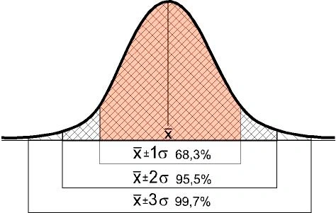

En nuestro caso, como se muestra en la imagen, los outliers se encuentran fuera del intervalo $\bar{x} \pm 3\sigma$.

# **Análisis de correlaciones entre variables**

Se analizan las correlaciones distinguiendo entre variables numéricas y categóricas. Para las numéricas se aplicará el coeficiente de correlación de Pearson, adecuado para medir relaciones lineales, mientras que para las categóricas se empleará la V de Cramer, que evalúa asociaciones entre variables cualitativas.

```python
correlation_matrix = pd_loan_train[list_var_continuous].corr(method='pearson')
correlation_matrix
```

|  | COMMONAREA_AVG | COMMONAREA_MODE | COMMONAREA_MEDI | NONLIVINGAPARTMENTS_AVG | NONLIVINGAPARTMENTS_MODE | NONLIVINGAPARTMENTS_MEDI | LIVINGAPARTMENTS_MEDI | LIVINGAPARTMENTS_AVG | LIVINGAPARTMENTS_MODE | FLOORSMIN_AVG | YEARS_BUILD_AVG | YEARS_BUILD_MEDI | YEARS_BUILD_MODE | OWN_CAR_AGE | LANDAREA_MEDI | LANDAREA_AVG | LANDAREA_MODE | BASEMENTAREA_MEDI | BASEMENTAREA_AVG | BASEMENTAREA_MODE | EXT_SOURCE_1 | NONLIVINGAREA_AVG | NONLIVINGAREA_MODE | NONLIVINGAREA_MEDI | ELEVATORS_AVG | APARTMENTS_AVG | APARTMENTS_MEDI | APARTMENTS_MODE | ENTRANCES_AVG | … |
| --- | --- | --- | --- | --- | --- | --- | --- | --- | --- | --- | --- | --- | --- | --- | --- | --- | --- | --- | --- | --- | --- | --- | --- | --- | --- | --- | --- | --- | --- | --- |
| COMMONAREA_AVG | 1.000000 | 0.975787 | 0.995470 | 0.104782 | 0.102665 | 0.104293 | 0.530616 | 0.529222 | 0.522006 | 0.292565 | 0.231779 | 0.231313 | 0.229314 | -0.031140 | 0.260300 | 0.259618 | 0.246267 | 0.403331 | 0.404464 | 0.386868 | 0.037240 | 0.227734 | 0.216085 | 0.226853 | 0.516861 | 0.534386 | 0.533793 | 0.512223 | 0.322833 | … |
| COMMONAREA_MODE | 0.975787 | 1.000000 | 0.979263 | 0.102252 | 0.107475 | 0.103637 | 0.522990 | 0.518888 | 0.534899 | 0.272735 | 0.223277 | 0.222851 | 0.227176 | -0.025601 | 0.271832 | 0.269844 | 0.268653 | 0.403923 | 0.400941 | 0.406678 | 0.030572 | 0.219810 | 0.227952 | 0.224095 | 0.499509 | 0.524887 | 0.527213 | 0.525222 | 0.330649 | … |
| COMMONAREA_MEDI | 0.995470 | 0.979263 | 1.000000 | 0.104888 | 0.103858 | 0.105272 | 0.533685 | 0.530163 | 0.525658 | 0.291047 | 0.232649 | 0.232532 | 0.230881 | -0.031037 | 0.263175 | 0.262139 | 0.249896 | 0.405949 | 0.406072 | 0.390166 | 0.036110 | 0.227934 | 0.218340 | 0.228696 | 0.517134 | 0.535665 | 0.537028 | 0.515847 | 0.324703 | … |
| NONLIVINGAPARTMENTS_AVG | 0.104782 | 0.102252 | 0.104888 | 1.000000 | 0.969309 | 0.990824 | 0.155643 | 0.158627 | 0.140652 | 0.074269 | 0.071085 | 0.070587 | 0.069802 | -0.024666 | 0.071804 | 0.069687 | 0.065638 | 0.096527 | 0.097188 | 0.092011 | 0.016574 | 0.223845 | 0.215411 | 0.223081 | 0.122926 | 0.194968 | 0.191882 | 0.181330 | 0.061973 | … |
| NONLIVINGAPARTMENTS_MODE | 0.102665 | 0.107475 | 0.103858 | 0.969309 | 1.000000 | 0.978500 | 0.146417 | 0.145301 | 0.144153 | 0.066655 | 0.064908 | 0.064866 | 0.066840 | -0.021657 | 0.068941 | 0.068106 | 0.068592 | 0.096412 | 0.095765 | 0.098056 | 0.014249 | 0.216177 | 0.220503 | 0.217537 | 0.116127 | 0.187296 | 0.187663 | 0.186392 | 0.064716 | … |
| NONLIVINGAPARTMENTS_MEDI | 0.104293 | 0.103637 | 0.105272 | 0.990824 | 0.978500 | 1.000000 | 0.156586 | 0.155699 | 0.142257 | 0.071888 | 0.069525 | 0.069381 | 0.068853 | -0.024032 | 0.068695 | 0.068043 | 0.063584 | 0.097179 | 0.097093 | 0.093584 | 0.015901 | 0.224038 | 0.217658 | 0.224750 | 0.122257 | 0.193101 | 0.193323 | 0.184063 | 0.063042 | … |
| LIVINGAPARTMENTS_MEDI | 0.530616 | 0.522990 | 0.533685 | 0.155643 | 0.146417 | 0.156586 | 1.000000 | 0.993293 | 0.975670 | 0.437776 | 0.334821 | 0.333822 | 0.333737 | -0.049948 | 0.428675 | 0.426473 | 0.418545 | 0.652785 | 0.650182 | 0.629806 | 0.050101 | 0.294223 | 0.278016 | 0.292947 | 0.814225 | 0.945306 | 0.946813 | 0.918900 | 0.569212 | … |
| LIVINGAPARTMENTS_AVG | 0.529222 | 0.518888 | 0.530163 | 0.158627 | 0.145301 | 0.155699 | 0.993293 | 1.000000 | 0.969751 | 0.438281 | 0.333595 | 0.332309 | 0.331736 | -0.050634 | 0.424502 | 0.423069 | 0.413508 | 0.647668 | 0.647892 | 0.624722 | 0.051668 | 0.293406 | 0.275245 | 0.290336 | 0.813190 | 0.948117 | 0.939385 | 0.912160 | 0.566385 | … |
| LIVINGAPARTMENTS_MODE | 0.522006 | 0.534899 | 0.525658 | 0.140652 | 0.144153 | 0.142257 | 0.975670 | 0.969751 | 1.000000 | 0.423957 | 0.325382 | 0.324360 | 0.331878 | -0.043353 | 0.439454 | 0.436727 | 0.441421 | 0.651721 | 0.647681 | 0.653929 | 0.044954 | 0.283761 | 0.287918 | 0.285736 | 0.797177 | 0.932201 | 0.934838 | 0.941466 | 0.576155 | … |
| FLOORSMIN_AVG | 0.292565 | 0.272735 | 0.291047 | 0.074269 | 0.066655 | 0.071888 | 0.437776 | 0.438281 | 0.423957 | 1.000000 | 0.355619 | 0.354760 | 0.348618 | -0.075735 | 0.150866 | 0.149545 | 0.139170 | 0.217849 | 0.221064 | 0.196902 | 0.078215 | 0.151837 | 0.128367 | 0.144487 | 0.510476 | 0.444474 | 0.441687 | 0.418495 | 0.036226 | … |
| YEARS_BUILD_AVG | 0.231779 | 0.223277 | 0.232649 | 0.071085 | 0.064908 | 0.069525 | 0.334821 | 0.333595 | 0.325382 | 0.355619 | 1.000000 | 0.998456 | 0.989516 | -0.050286 | 0.181016 | 0.180491 | 0.169273 | 0.245499 | 0.247811 | 0.232548 | 0.015208 | 0.127133 | 0.111164 | 0.124241 | 0.342736 | 0.340000 | 0.338439 | 0.321959 | 0.088047 | … |
| YEARS_BUILD_MEDI | 0.231313 | 0.222851 | 0.232532 | 0.070587 | 0.064866 | 0.069381 | 0.333822 | 0.332309 | 0.324360 | 0.354760 | 0.998456 | 1.000000 | 0.989616 | -0.049749 | 0.180766 | 0.180338 | 0.169170 | 0.244844 | 0.246991 | 0.232050 | 0.014982 | 0.127167 | 0.111383 | 0.124477 | 0.341840 | 0.338802 | 0.337546 | 0.321115 | 0.087336 | … |
| YEARS_BUILD_MODE | 0.229314 | 0.227176 | 0.230881 | 0.069802 | 0.066840 | 0.068853 | 0.333737 | 0.331736 | 0.331878 | 0.348618 | 0.989516 | 0.989616 | 1.000000 | -0.048587 | 0.184725 | 0.183548 | 0.178576 | 0.247207 | 0.248657 | 0.242809 | 0.014117 | 0.124628 | 0.116373 | 0.123876 | 0.338778 | 0.338468 | 0.337883 | 0.328946 | 0.092633 | … |
| OWN_CAR_AGE | -0.031140 | -0.025601 | -0.031037 | -0.024666 | -0.021657 | -0.024032 | -0.049948 | -0.050634 | -0.043353 | -0.075735 | -0.050286 | -0.049749 | -0.048587 | 1.000000 | -0.021406 | -0.021510 | -0.018867 | -0.029469 | -0.031210 | -0.025004 | -0.082060 | -0.031511 | -0.028714 | -0.030869 | -0.065509 | -0.050905 | -0.049750 | -0.044196 | -0.017600 | … |
| LANDAREA_MEDI | 0.260300 | 0.271832 | 0.263175 | 0.071804 | 0.068941 | 0.068695 | 0.428675 | 0.424502 | 0.439454 | 0.150866 | 0.181016 | 0.180766 | 0.184725 | -0.021406 | 1.000000 | 0.992961 | 0.979888 | 0.470946 | 0.469020 | 0.474067 | 0.003860 | 0.163851 | 0.163360 | 0.166492 | 0.374825 | 0.498726 | 0.500733 | 0.500736 | 0.509705 | … |
| LANDAREA_AVG | 0.259618 | 0.269844 | 0.262139 | 0.069687 | 0.068106 | 0.068043 | 0.426473 | 0.423069 | 0.436727 | 0.149545 | 0.180491 | 0.180338 | 0.183548 | -0.021510 | 0.992961 | 1.000000 | 0.973956 | 0.468920 | 0.467405 | 0.470685 | 0.004033 | 0.164056 | 0.162080 | 0.165377 | 0.374036 | 0.497188 | 0.498098 | 0.497420 | 0.507269 | … |
| LANDAREA_MODE | 0.246267 | 0.268653 | 0.249896 | 0.065638 | 0.068592 | 0.063584 | 0.418545 | 0.413508 | 0.441421 | 0.139170 | 0.169273 | 0.169170 | 0.178576 | -0.018867 | 0.979888 | 0.973956 | 1.000000 | 0.464010 | 0.460803 | 0.482450 | 0.001390 | 0.157325 | 0.170535 | 0.161682 | 0.359047 | 0.487099 | 0.489694 | 0.507886 | 0.509773 | … |
| BASEMENTAREA_MEDI | 0.403331 | 0.403923 | 0.405949 | 0.096527 | 0.096412 | 0.097179 | 0.652785 | 0.647668 | 0.651721 | 0.217849 | 0.245499 | 0.244844 | 0.247207 | -0.029469 | 0.470946 | 0.468920 | 0.464010 | 1.000000 | 0.994452 | 0.977493 | 0.043124 | 0.265766 | 0.262005 | 0.266808 | 0.560217 | 0.677465 | 0.679074 | 0.667139 | 0.650593 | … |
| BASEMENTAREA_AVG | 0.404464 | 0.400941 | 0.406072 | 0.097188 | 0.095765 | 0.097093 | 0.650182 | 0.647892 | 0.647681 | 0.221064 | 0.247811 | 0.246991 | 0.248657 | -0.031210 | 0.469020 | 0.467405 | 0.460803 | 0.994452 | 1.000000 | 0.973196 | 0.043649 | 0.266209 | 0.259450 | 0.264907 | 0.562350 | 0.678119 | 0.676933 | 0.664514 | 0.648824 | … |
| BASEMENTAREA_MODE | 0.386868 | 0.406678 | 0.390166 | 0.092011 | 0.098056 | 0.093584 | 0.629806 | 0.624722 | 0.653929 | 0.196902 | 0.232548 | 0.232050 | 0.242809 | -0.025004 | 0.474067 | 0.470685 | 0.482450 | 0.977493 | 0.973196 | 1.000000 | 0.038601 | 0.255993 | 0.271617 | 0.260575 | 0.536601 | 0.659373 | 0.661945 | 0.676714 | 0.651627 | … |
| EXT_SOURCE_1 | 0.037240 | 0.030572 | 0.036110 | 0.016574 | 0.014249 | 0.015901 | 0.050101 | 0.051668 | 0.044954 | 0.078215 | 0.015208 | 0.014982 | 0.014117 | -0.082060 | 0.003860 | 0.004033 | 0.001390 | 0.043124 | 0.043649 | 0.038601 | 1.000000 | 0.035291 | 0.030384 | 0.034203 | 0.077752 | 0.059113 | 0.057532 | 0.053305 | 0.026022 | … |
| NONLIVINGAREA_AVG | 0.227734 | 0.219810 | 0.227934 | 0.223845 | 0.216177 | 0.224038 | 0.294223 | 0.293406 | 0.283761 | 0.151837 | 0.127133 | 0.127167 | 0.124628 | -0.031511 | 0.163851 | 0.164056 | 0.157325 | 0.265766 | 0.266209 | 0.255993 | 0.035291 | 1.000000 | 0.965784 | 0.990468 | 0.285101 | 0.301522 | 0.298928 | 0.289297 | 0.163474 | … |
| NONLIVINGAREA_MODE | 0.216085 | 0.227952 | 0.218340 | 0.215411 | 0.220503 | 0.217658 | 0.278016 | 0.275245 | 0.287918 | 0.128367 | 0.111164 | 0.111383 | 0.116373 | -0.028714 | 0.163360 | 0.162080 | 0.170535 | 0.262005 | 0.259450 | 0.271617 | 0.030384 | 0.965784 | 1.000000 | 0.975574 | 0.265599 | 0.285790 | 0.286669 | 0.295847 | 0.168553 | … |
| NONLIVINGAREA_MEDI | 0.226853 | 0.224095 | 0.228696 | 0.223081 | 0.217537 | 0.224750 | 0.292947 | 0.290336 | 0.285736 | 0.144487 | 0.124241 | 0.124477 | 0.123876 | -0.030869 | 0.166492 | 0.165377 | 0.161682 | 0.266808 | 0.264907 | 0.260575 | 0.034203 | 0.990468 | 0.975574 | 1.000000 | 0.281753 | 0.299175 | 0.299194 | 0.291884 | 0.164756 | … |
| ELEVATORS_AVG | 0.516861 | 0.499509 | 0.517134 | 0.122926 | 0.116127 | 0.122257 | 0.814225 | 0.813190 | 0.797177 | 0.510476 | 0.342736 | 0.341840 | 0.338778 | -0.065509 | 0.374825 | 0.374036 | 0.359047 | 0.560217 | 0.562350 | 0.536601 | 0.077752 | 0.285101 | 0.265599 | 0.281753 | 1.000000 | 0.834755 | 0.832303 | 0.803638 | 0.402439 | … |
| APARTMENTS_AVG | 0.534386 | 0.524887 | 0.535665 | 0.194968 | 0.187296 | 0.193101 | 0.945306 | 0.948117 | 0.932201 | 0.444474 | 0.340000 | 0.338802 | 0.338468 | -0.050905 | 0.498726 | 0.497188 | 0.487099 | 0.677465 | 0.678119 | 0.659373 | 0.059113 | 0.301522 | 0.285790 | 0.299175 | 0.834755 | 1.000000 | 0.994903 | 0.972968 | 0.609679 | … |
| APARTMENTS_MEDI | 0.533793 | 0.527213 | 0.537028 | 0.191882 | 0.187663 | 0.193323 | 0.946813 | 0.939385 | 0.934838 | 0.441687 | 0.338439 | 0.337546 | 0.337883 | -0.049750 | 0.500733 | 0.498098 | 0.489694 | 0.679074 | 0.676933 | 0.661945 | 0.057532 | 0.298928 | 0.286669 | 0.299194 | 0.832303 | 0.994903 | 1.000000 | 0.977107 | 0.610208 | … |
| APARTMENTS_MODE | 0.512223 | 0.525222 | 0.515847 | 0.181330 | 0.186392 | 0.184063 | 0.918900 | 0.912160 | 0.941466 | 0.418495 | 0.321959 | 0.321115 | 0.328946 | -0.044196 | 0.500736 | 0.497420 | 0.507886 | 0.667139 | 0.664514 | 0.676714 | 0.053305 | 0.289297 | 0.295847 | 0.291884 | 0.803638 | 0.972968 | 0.977107 | 1.000000 | 0.611172 | … |
| ENTRANCES_AVG | 0.322833 | 0.330649 | 0.324703 | 0.061973 | 0.064716 | 0.063042 | 0.569212 | 0.566385 | 0.576155 | 0.036226 | 0.088047 | 0.087336 | 0.092633 | -0.017600 | 0.509705 | 0.507269 | 0.509773 | 0.650593 | 0.648824 | 0.651627 | 0.026022 | 0.163474 | 0.168553 | 0.164756 | 0.402439 | 0.609679 | 0.610208 | 0.611172 | 1.000000 | … |
| LIVINGAREA_MEDI | 0.539749 | 0.532613 | 0.543014 | 0.134499 | 0.129904 | 0.135245 | 0.887337 | 0.880416 | 0.875350 | 0.462232 | 0.352887 | 0.352161 | 0.351863 | -0.058883 | 0.503118 | 0.501030 | 0.491288 | 0.690050 | 0.688122 | 0.671657 | 0.071280 | 0.299166 | 0.285263 | 0.298941 | 0.864752 | 0.911624 | 0.915377 | 0.893633 | 0.618136 | … |
| LIVINGAREA_MODE | 0.518804 | 0.533081 | 0.522407 | 0.127558 | 0.131661 | 0.129302 | 0.860366 | 0.854369 | 0.881022 | 0.438247 | 0.336726 | 0.335938 | 0.343455 | -0.054130 | 0.503945 | 0.500964 | 0.511360 | 0.679082 | 0.675947 | 0.688710 | 0.066699 | 0.287484 | 0.295794 | 0.290974 | 0.837450 | 0.892486 | 0.895312 | 0.909697 | 0.621495 | … |
| LIVINGAREA_AVG | 0.540949 | 0.531137 | 0.542459 | 0.135474 | 0.129966 | 0.135594 | 0.885848 | 0.883042 | 0.874139 | 0.464824 | 0.353938 | 0.352903 | 0.351878 | -0.059991 | 0.502627 | 0.501310 | 0.489917 | 0.691587 | 0.691981 | 0.672722 | 0.072587 | 0.303313 | 0.286448 | 0.301031 | 0.867049 | 0.913043 | 0.912063 | 0.890276 | 0.617647 | … |
| FLOORSMAX_AVG | 0.401366 | 0.375252 | 0.400408 | 0.114002 | 0.102717 | 0.111808 | 0.590964 | 0.591889 | 0.568908 | 0.740889 | 0.517344 | 0.516105 | 0.507180 | -0.085960 | 0.221084 | 0.221373 | 0.204400 | 0.326382 | 0.330489 | 0.298800 | 0.096320 | 0.255596 | 0.226201 | 0.248568 | 0.680607 | 0.619718 | 0.616133 | 0.586667 | 0.088228 | … |
| YEARS_BEGINEXPLUATATION_MEDI | 0.079508 | 0.074645 | 0.079840 | 0.031194 | 0.028237 | 0.030539 | 0.126743 | 0.126329 | 0.121484 | 0.147258 | 0.430814 | 0.431359 | 0.426335 | -0.000398 | 0.068121 | 0.068095 | 0.063926 | 0.077788 | 0.078513 | 0.073126 | 0.003993 | 0.012960 | 0.008168 | 0.011975 | 0.078370 | 0.099865 | 0.100174 | 0.099941 | 0.040672 | … |
| YEARS_BEGINEXPLUATATION_MODE | 0.053502 | 0.051716 | 0.053702 | 0.019900 | 0.018477 | 0.019495 | 0.084481 | 0.084193 | 0.082627 | 0.096840 | 0.290343 | 0.290346 | 0.292606 | 0.001096 | 0.049466 | 0.049376 | 0.048154 | 0.058271 | 0.058840 | 0.057151 | 0.003439 | -0.006657 | -0.000865 | -0.007427 | 0.072987 | 0.095491 | 0.095786 | 0.100952 | 0.037808 | … |
| YEARS_BEGINEXPLUATATION_AVG | 0.096778 | 0.091806 | 0.097142 | 0.034667 | 0.031250 | 0.033820 | 0.149427 | 0.148896 | 0.143853 | 0.168036 | 0.489034 | 0.488396 | 0.483361 | -0.000649 | 0.073223 | 0.073179 | 0.069028 | 0.085538 | 0.086230 | 0.080896 | 0.004156 | 0.011519 | 0.010103 | 0.010324 | 0.079479 | 0.100317 | 0.100329 | 0.100699 | 0.041972 | … |
| TOTALAREA_MODE | 0.549188 | 0.539663 | 0.549022 | 0.144141 | 0.137993 | 0.143578 | 0.847921 | 0.849941 | 0.834904 | 0.453288 | 0.359113 | 0.357734 | 0.355535 | -0.060275 | 0.491946 | 0.491206 | 0.477311 | 0.668989 | 0.672144 | 0.648265 | 0.070397 | 0.368658 | 0.348587 | 0.363633 | 0.843821 | 0.892124 | 0.885973 | 0.863341 | 0.593926 | … |
| EXT_SOURCE_3 | -0.003513 | -0.003051 | -0.003682 | 0.009546 | 0.008750 | 0.009059 | 0.003148 | 0.003606 | 0.003494 | 0.004781 | 0.018194 | 0.017957 | 0.017483 | -0.014531 | 0.009305 | 0.009245 | 0.007911 | 0.008700 | 0.008927 | 0.007291 | 0.187796 | -0.001942 | -0.002350 | -0.002311 | 0.008957 | 0.006068 | 0.005771 | 0.005045 | 0.014012 | … |
| EXT_SOURCE_2 | 0.054702 | 0.045156 | 0.053311 | 0.020291 | 0.017128 | 0.019030 | 0.080164 | 0.081943 | 0.072702 | 0.113624 | 0.013900 | 0.013578 | 0.011242 | -0.082472 | 0.020052 | 0.020851 | 0.016272 | 0.048599 | 0.050206 | 0.039446 | 0.215210 | 0.046283 | 0.038694 | 0.043825 | 0.115085 | 0.091482 | 0.089788 | 0.080620 | 0.032724 | … |
| AMT_GOODS_PRICE | 0.051567 | 0.044284 | 0.050694 | 0.014185 | 0.010218 | 0.013202 | 0.058809 | 0.060551 | 0.052264 | 0.080890 | 0.041046 | 0.040685 | 0.038211 | -0.103849 | 0.010807 | 0.011148 | 0.007908 | 0.042650 | 0.044704 | 0.036304 | 0.176309 | 0.042419 | 0.036765 | 0.040117 | 0.083859 | 0.064844 | 0.063177 | 0.057474 | 0.019080 | … |
| AMT_ANNUITY | 0.059771 | 0.051456 | 0.059174 | 0.021880 | 0.016801 | 0.021044 | 0.071856 | 0.074306 | 0.064429 | 0.097883 | 0.033694 | 0.033147 | 0.029995 | -0.098148 | 0.007663 | 0.008011 | 0.003432 | 0.043540 | 0.045699 | 0.035575 | 0.121397 | 0.049911 | 0.041797 | 0.047123 | 0.102088 | 0.077390 | 0.075146 | 0.067529 | 0.016323 | … |
| DAYS_LAST_PHONE_CHANGE | -0.005705 | -0.003412 | -0.005257 | 0.002072 | 0.001132 | 0.001748 | -0.004664 | -0.005145 | -0.005145 | -0.010393 | 0.012927 | 0.012748 | 0.012991 | 0.001123 | -0.000577 | -0.000200 | -0.000390 | -0.007105 | -0.006643 | -0.005264 | -0.131218 | -0.001977 | -0.001315 | -0.002010 | -0.010821 | -0.008951 | -0.008924 | -0.007480 | -0.010682 | … |
| AMT_INCOME_TOTAL | 0.092241 | 0.077933 | 0.090718 | 0.031674 | 0.026623 | 0.030034 | 0.105386 | 0.107658 | 0.092569 | 0.138546 | 0.041943 | 0.041561 | 0.037313 | -0.116452 | -0.001296 | -0.001214 | -0.002957 | 0.015082 | 0.015983 | 0.011790 | 0.024040 | 0.077540 | 0.064844 | 0.073555 | 0.040215 | 0.031333 | 0.030666 | 0.027279 | 0.005410 | … |
| AMT_CREDIT | 0.050500 | 0.043376 | 0.049613 | 0.013228 | 0.009478 | 0.012268 | 0.055466 | 0.057227 | 0.049345 | 0.078673 | 0.035030 | 0.034730 | 0.032302 | -0.094312 | 0.003647 | 0.004010 | 0.000981 | 0.037721 | 0.039753 | 0.031513 | 0.169385 | 0.038224 | 0.032587 | 0.035917 | 0.080984 | 0.060366 | 0.058651 | 0.052886 | 0.015074 | … |
| DAYS_REGISTRATION | 0.028150 | 0.029073 | 0.029131 | 0.033447 | 0.030580 | 0.032739 | 0.022883 | 0.022317 | 0.020926 | 0.019890 | 0.165998 | 0.165874 | 0.164331 | -0.027436 | 0.003282 | 0.003053 | 0.003201 | -0.022957 | -0.022238 | -0.022096 | -0.182768 | 0.048693 | 0.046690 | 0.049576 | -0.000299 | 0.012476 | 0.012672 | 0.011469 | -0.065665 | … |
| REGION_POPULATION_RELATIVE | 0.163566 | 0.129032 | 0.158644 | 0.024122 | 0.015984 | 0.021697 | 0.188862 | 0.194374 | 0.162315 | 0.290971 | -0.059537 | -0.060887 | -0.066677 | -0.082579 | -0.051752 | -0.050462 | -0.060980 | 0.093543 | 0.098195 | 0.065007 | 0.101110 | 0.076516 | 0.051042 | 0.067550 | 0.278682 | 0.204486 | 0.199805 | 0.173158 | 0.037118 | … |

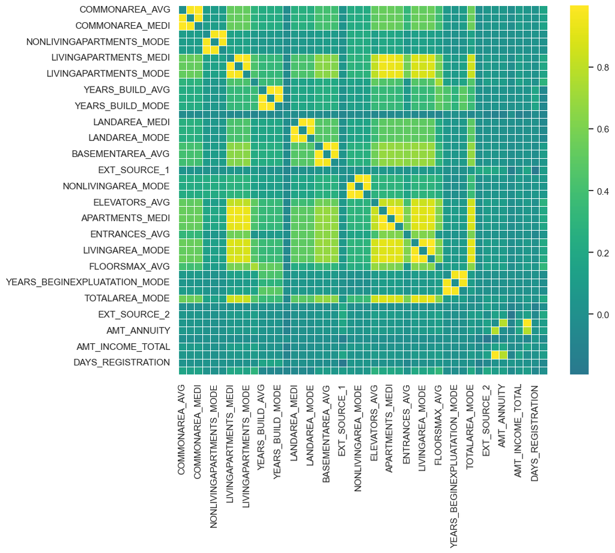

```
0
```

```python
f_aux.get_corr_matrix(dataset = pd_loan_train[list_var_continuous],
                metodo='pearson', size_figure=[10,8])
```

```python
corr = pd_loan_train[list_var_continuous].corr('pearson')
new_corr = corr.abs()
new_corr.loc[:,:] = np.tril(new_corr, k=-1) # below main lower triangle of an array
new_corr = new_corr.stack().to_frame('correlation').reset_index().sort_values(by='correlation', ascending=False)
new_corr[new_corr['correlation']>0.6]
```

|  | level_0 | level_1 | correlation |
| --- | --- | --- | --- |
| 516 | YEARS_BUILD_MEDI | YEARS_BUILD_AVG | 0.998456 |
| 1455 | LIVINGAREA_AVG | LIVINGAREA_MEDI | 0.995732 |
| 92 | COMMONAREA_MEDI | COMMONAREA_AVG | 0.995470 |
| 1221 | APARTMENTS_MEDI | APARTMENTS_AVG | 0.994903 |
| 845 | BASEMENTAREA_AVG | BASEMENTAREA_MEDI | 0.994452 |
| 1643 | YEARS_BEGINEXPLUATATION_AVG | YEARS_BEGINEXPLUATATION_MEDI | 0.993954 |
| 328 | LIVINGAPARTMENTS_AVG | LIVINGAPARTMENTS_MEDI | 0.993293 |
| 704 | LANDAREA_AVG | LANDAREA_MEDI | 0.992961 |
| 233 | NONLIVINGAPARTMENTS_MEDI | NONLIVINGAPARTMENTS_AVG | 0.990824 |
| 1079 | NONLIVINGAREA_MEDI | NONLIVINGAREA_AVG | 0.990468 |
| 563 | YEARS_BUILD_MODE | YEARS_BUILD_MEDI | 0.989616 |
| 562 | YEARS_BUILD_MODE | YEARS_BUILD_AVG | 0.989516 |
| 2017 | AMT_CREDIT | AMT_GOODS_PRICE | 0.986922 |
| 750 | LANDAREA_MODE | LANDAREA_MEDI | 0.979888 |
| 93 | COMMONAREA_MEDI | COMMONAREA_MODE | 0.979263 |
| 234 | NONLIVINGAPARTMENTS_MEDI | NONLIVINGAPARTMENTS_MODE | 0.978500 |
| 891 | BASEMENTAREA_MODE | BASEMENTAREA_MEDI | 0.977493 |
| 1268 | APARTMENTS_MODE | APARTMENTS_MEDI | 0.977107 |
| 46 | COMMONAREA_MODE | COMMONAREA_AVG | 0.975787 |
| 374 | LIVINGAPARTMENTS_MODE | LIVINGAPARTMENTS_MEDI | 0.975670 |
| 1080 | NONLIVINGAREA_MEDI | NONLIVINGAREA_MODE | 0.975574 |
| 1409 | LIVINGAREA_MODE | LIVINGAREA_MEDI | 0.974914 |
| 751 | LANDAREA_MODE | LANDAREA_AVG | 0.973956 |
| 892 | BASEMENTAREA_MODE | BASEMENTAREA_AVG | 0.973196 |
| 1267 | APARTMENTS_MODE | APARTMENTS_AVG | 0.972968 |
| 1644 | YEARS_BEGINEXPLUATATION_AVG | YEARS_BEGINEXPLUATATION_MODE | 0.972784 |
| 1456 | LIVINGAREA_AVG | LIVINGAREA_MODE | 0.972421 |
| 375 | LIVINGAPARTMENTS_MODE | LIVINGAPARTMENTS_AVG | 0.969751 |
| 187 | NONLIVINGAPARTMENTS_MODE | NONLIVINGAPARTMENTS_AVG | 0.969309 |
| 1033 | NONLIVINGAREA_MODE | NONLIVINGAREA_AVG | 0.965784 |

[output cut: 95 more lines]

El resultado muestra una alta colinealidad entre las variables continuas, lo que sugiere que algunas podrían eliminarse para evitar redundancia y multicolinealidad, ya que aportan información muy similar. Sin embargo, en este caso se opta por conservar todas las variables para analizar su influencia individual

# **Tratamiento de valores nulos**

El manejo de valores nulos es un paso fundamental en el preprocesamiento de datos, ya que estos valores ausentes pueden alterar los resultados de un análisis o afectar negativamente el desempeño de un modelo de machine learning. La estrategia para tratar valores nulos depende del tipo de variable, la cantidad de datos faltantes y el objetivo del análisis. Existen múltiples enfoques que pueden aplicarse dependiendo del contexto:

1. Imputar los valores numéricos utilizando la media o la mediana. Otra posible opción es la de imputar un valor fijo, el máximo o el mínimo.
2. En el caso de las variables categóricas, una alternativa podría ser asignar categorías específicas como "Desconocido" o "No aplicable".
3. Para las variables booleanas, donde los valores son 0 o 1, una solución eficiente es reemplazar los valores faltantes con la moda, ya que esta suele representar la categoría dominante en este tipo de variables.

Además, en situaciones donde los valores nulos son excesivos, se puede considerar su eliminación directa. Sin embargo, esto debe hacerse con cuidado para no perder información relevante.

```python
f_aux.get_percent_null_values_target(pd_loan_train, list_var_continuous, target='TARGET')
```

|  | 0.0 | 1.0 | variable | sum_null_values | porcentaje_sum_null_values |
| --- | --- | --- | --- | --- | --- |
| 0 | 0.000000 | 1.000000 | COMMONAREA_AVG | 171853 | 0.698567 |
| 1 | 0.914287 | 0.085713 | COMMONAREA_AVG | 171853 | 0.698567 |
| 2 | 0.000000 | 1.000000 | COMMONAREA_MODE | 171853 | 0.698567 |
| 3 | 0.914287 | 0.085713 | COMMONAREA_MODE | 171853 | 0.698567 |
| 4 | 0.000000 | 1.000000 | COMMONAREA_MEDI | 171853 | 0.698567 |
| 5 | 0.914287 | 0.085713 | COMMONAREA_MEDI | 171853 | 0.698567 |
| 6 | 0.000000 | 1.000000 | NONLIVINGAPARTMENTS_AVG | 170767 | 0.694152 |
| 7 | 0.914152 | 0.085848 | NONLIVINGAPARTMENTS_AVG | 170767 | 0.694152 |
| 8 | 0.000000 | 1.000000 | NONLIVINGAPARTMENTS_MODE | 170767 | 0.694152 |
| 9 | 0.914152 | 0.085848 | NONLIVINGAPARTMENTS_MODE | 170767 | 0.694152 |
| 10 | 0.000000 | 1.000000 | NONLIVINGAPARTMENTS_MEDI | 170767 | 0.694152 |
| 11 | 0.914152 | 0.085848 | NONLIVINGAPARTMENTS_MEDI | 170767 | 0.694152 |
| 12 | 0.000000 | 1.000000 | LIVINGAPARTMENTS_MEDI | 168129 | 0.683429 |
| 13 | 0.913757 | 0.086243 | LIVINGAPARTMENTS_MEDI | 168129 | 0.683429 |
| 14 | 0.000000 | 1.000000 | LIVINGAPARTMENTS_AVG | 168129 | 0.683429 |
| 15 | 0.913757 | 0.086243 | LIVINGAPARTMENTS_AVG | 168129 | 0.683429 |
| 16 | 0.000000 | 1.000000 | LIVINGAPARTMENTS_MODE | 168129 | 0.683429 |
| 17 | 0.913757 | 0.086243 | LIVINGAPARTMENTS_MODE | 168129 | 0.683429 |
| 18 | 0.000000 | 1.000000 | FLOORSMIN_AVG | 166905 | 0.678454 |
| 19 | 0.913705 | 0.086295 | FLOORSMIN_AVG | 166905 | 0.678454 |
| 20 | 0.000000 | 1.000000 | YEARS_BUILD_AVG | 163604 | 0.665035 |
| 21 | 0.913211 | 0.086789 | YEARS_BUILD_AVG | 163604 | 0.665035 |
| 22 | 0.000000 | 1.000000 | YEARS_BUILD_MEDI | 163604 | 0.665035 |
| 23 | 0.913211 | 0.086789 | YEARS_BUILD_MEDI | 163604 | 0.665035 |
| 24 | 0.000000 | 1.000000 | YEARS_BUILD_MODE | 163604 | 0.665035 |
| 25 | 0.913211 | 0.086789 | YEARS_BUILD_MODE | 163604 | 0.665035 |
| 26 | 0.000000 | 1.000000 | OWN_CAR_AGE | 162380 | 0.660060 |
| 27 | 0.915248 | 0.084752 | OWN_CAR_AGE | 162380 | 0.660060 |
| 28 | 0.000000 | 1.000000 | LANDAREA_MEDI | 146070 | 0.593761 |
| 29 | 0.911809 | 0.088191 | LANDAREA_MEDI | 146070 | 0.593761 |

[output cut: 54 more lines]

Decido sustituir los valores nulos por la mediana pues la mayoría de variables numéricas presentan una gran cantidad de outliers. Por ello, el valor más representativo de estas será la mediana.

```python
# Reemplazar nulos en el conjunto de entrenamiento con la mediana de cada columna
pd_loan_train[list_var_continuous] = pd_loan_train[list_var_continuous].fillna(pd_loan_train[list_var_continuous].median())

# Reemplazar nulos en el conjunto de test con las mismas medianas calculadas en el conjunto de entrenamiento
pd_loan_test[list_var_continuous] = pd_loan_test[list_var_continuous].fillna(pd_loan_train[list_var_continuous].median())

# Mostramos los df para verificar que ya no hay nulos
pd_loan_train[list_var_continuous]
```

|  | COMMONAREA_AVG | COMMONAREA_MODE | COMMONAREA_MEDI | NONLIVINGAPARTMENTS_AVG | NONLIVINGAPARTMENTS_MODE | NONLIVINGAPARTMENTS_MEDI | LIVINGAPARTMENTS_MEDI | LIVINGAPARTMENTS_AVG | LIVINGAPARTMENTS_MODE | FLOORSMIN_AVG | YEARS_BUILD_AVG | YEARS_BUILD_MEDI | YEARS_BUILD_MODE | OWN_CAR_AGE | LANDAREA_MEDI | LANDAREA_AVG | LANDAREA_MODE | BASEMENTAREA_MEDI | BASEMENTAREA_AVG | BASEMENTAREA_MODE | EXT_SOURCE_1 | NONLIVINGAREA_AVG | NONLIVINGAREA_MODE | NONLIVINGAREA_MEDI | ELEVATORS_AVG | APARTMENTS_AVG | APARTMENTS_MEDI | APARTMENTS_MODE | ENTRANCES_AVG | … |
| --- | --- | --- | --- | --- | --- | --- | --- | --- | --- | --- | --- | --- | --- | --- | --- | --- | --- | --- | --- | --- | --- | --- | --- | --- | --- | --- | --- | --- | --- | --- |
| 236327 | 0.0211 | 0.0191 | 0.0209 | 0.0 | 0.0 | 0.0 | 0.0342 | 0.0336 | 0.0367 | 0.1667 | 0.6192 | 0.6243 | 0.6341 | 9.0 | 0.0150 | 0.0148 | 0.0151 | 0.0482 | 0.0482 | 0.0500 | 0.652913 | 0.0000 | 0.0000 | 0.0000 | 0.0 | 0.0412 | 0.0416 | 0.0420 | 0.0690 | … |
| 23526 | 0.0211 | 0.0191 | 0.0209 | 0.0 | 0.0 | 0.0 | 0.0761 | 0.0756 | 0.0771 | 0.2083 | 0.7552 | 0.7585 | 0.7648 | 4.0 | 0.0488 | 0.0483 | 0.0460 | 0.0758 | 0.0763 | 0.0746 | 0.417335 | 0.0036 | 0.0011 | 0.0031 | 0.0 | 0.0876 | 0.0874 | 0.0840 | 0.1379 | … |
| 142647 | 0.0211 | 0.0191 | 0.0209 | 0.0 | 0.0 | 0.0 | 0.0761 | 0.0756 | 0.0771 | 0.2083 | 0.7552 | 0.7585 | 0.7648 | 9.0 | 0.0488 | 0.0483 | 0.0460 | 0.0758 | 0.0763 | 0.0746 | 0.505176 | 0.0036 | 0.0011 | 0.0031 | 0.0 | 0.0876 | 0.0874 | 0.0840 | 0.1379 | … |
| 294722 | 0.0211 | 0.0191 | 0.0209 | 0.0 | 0.0 | 0.0 | 0.0761 | 0.0756 | 0.0771 | 0.2083 | 0.7552 | 0.7585 | 0.7648 | 1.0 | 0.0488 | 0.0483 | 0.0460 | 0.0758 | 0.0763 | 0.0746 | 0.505176 | 0.0036 | 0.0011 | 0.0031 | 0.0 | 0.0876 | 0.0874 | 0.0840 | 0.1379 | … |
| 119381 | 0.0211 | 0.0191 | 0.0209 | 0.0 | 0.0 | 0.0 | 0.0761 | 0.0756 | 0.0771 | 0.2083 | 0.7552 | 0.7585 | 0.7648 | 18.0 | 0.0488 | 0.0483 | 0.0460 | 0.0758 | 0.0763 | 0.0746 | 0.254716 | 0.0036 | 0.0011 | 0.0031 | 0.0 | 0.0876 | 0.0874 | 0.0840 | 0.1379 | … |
| ... | ... | ... | ... | ... | ... | ... | ... | ... | ... | ... | ... | ... | ... | ... | ... | ... | ... | ... | ... | ... | ... | ... | ... | ... | ... | ... | ... | ... | ... | … |
| 158780 | 0.0211 | 0.0191 | 0.0209 | 0.0 | 0.0 | 0.0 | 0.0761 | 0.0756 | 0.0771 | 0.2083 | 0.7552 | 0.7585 | 0.7648 | 9.0 | 0.0488 | 0.0483 | 0.0460 | 0.0758 | 0.0763 | 0.0746 | 0.505176 | 0.0036 | 0.0011 | 0.0031 | 0.0 | 0.0876 | 0.0874 | 0.0840 | 0.1379 | … |
| 179956 | 0.0211 | 0.0191 | 0.0209 | 0.0 | 0.0 | 0.0 | 0.0761 | 0.0756 | 0.0771 | 0.2083 | 0.7552 | 0.7585 | 0.7648 | 9.0 | 0.0488 | 0.0483 | 0.0460 | 0.0758 | 0.0763 | 0.0746 | 0.505176 | 0.0036 | 0.0011 | 0.0031 | 0.0 | 0.0876 | 0.0874 | 0.0840 | 0.1379 | … |
| 298923 | 0.0211 | 0.0191 | 0.0209 | 0.0 | 0.0 | 0.0 | 0.0761 | 0.0756 | 0.0771 | 0.2083 | 0.7552 | 0.7585 | 0.7648 | 8.0 | 0.0488 | 0.0483 | 0.0460 | 0.0758 | 0.0763 | 0.0746 | 0.339361 | 0.0036 | 0.0011 | 0.0031 | 0.0 | 0.0454 | 0.0458 | 0.0462 | 0.1034 | … |
| 43143 | 0.0183 | 0.0185 | 0.0184 | 0.0 | 0.0 | 0.0 | 0.1026 | 0.1009 | 0.1102 | 0.2083 | 0.7552 | 0.7585 | 0.7648 | 12.0 | 0.0685 | 0.0673 | 0.0689 | 0.0797 | 0.0797 | 0.0827 | 0.505176 | 0.0000 | 0.0000 | 0.0000 | 0.0 | 0.1237 | 0.1249 | 0.1261 | 0.2069 | … |
| 43350 | 0.0211 | 0.0191 | 0.0209 | 0.0 | 0.0 | 0.0 | 0.0761 | 0.0756 | 0.0771 | 0.2083 | 0.7552 | 0.7585 | 0.7648 | 36.0 | 0.0488 | 0.0483 | 0.0460 | 0.0758 | 0.0763 | 0.0746 | 0.507503 | 0.0036 | 0.0011 | 0.0031 | 0.0 | 0.0876 | 0.0874 | 0.0840 | 0.1379 | … |

246008 rows × 46 columns

```python
pd_loan_test[list_var_continuous]
```

|  | COMMONAREA_AVG | COMMONAREA_MODE | COMMONAREA_MEDI | NONLIVINGAPARTMENTS_AVG | NONLIVINGAPARTMENTS_MODE | NONLIVINGAPARTMENTS_MEDI | LIVINGAPARTMENTS_MEDI | LIVINGAPARTMENTS_AVG | LIVINGAPARTMENTS_MODE | FLOORSMIN_AVG | YEARS_BUILD_AVG | YEARS_BUILD_MEDI | YEARS_BUILD_MODE | OWN_CAR_AGE | LANDAREA_MEDI | LANDAREA_AVG | LANDAREA_MODE | BASEMENTAREA_MEDI | BASEMENTAREA_AVG | BASEMENTAREA_MODE | EXT_SOURCE_1 | NONLIVINGAREA_AVG | NONLIVINGAREA_MODE | NONLIVINGAREA_MEDI | ELEVATORS_AVG | APARTMENTS_AVG | APARTMENTS_MEDI | APARTMENTS_MODE | ENTRANCES_AVG | … |
| --- | --- | --- | --- | --- | --- | --- | --- | --- | --- | --- | --- | --- | --- | --- | --- | --- | --- | --- | --- | --- | --- | --- | --- | --- | --- | --- | --- | --- | --- | --- |
| 186741 | 0.0211 | 0.0191 | 0.0209 | 0.0 | 0.0 | 0.0 | 0.0761 | 0.0756 | 0.0771 | 0.2083 | 0.7552 | 0.7585 | 0.7648 | 9.0 | 0.0488 | 0.0483 | 0.0460 | 0.0758 | 0.0763 | 0.0746 | 0.535588 | 0.0036 | 0.0011 | 0.0031 | 0.00 | 0.0876 | 0.0874 | 0.0840 | 0.1379 | … |
| 175947 | 0.0211 | 0.0191 | 0.0209 | 0.0 | 0.0 | 0.0 | 0.0761 | 0.0756 | 0.0771 | 0.2083 | 0.7552 | 0.7585 | 0.7648 | 9.0 | 0.0488 | 0.0483 | 0.0460 | 0.0758 | 0.0763 | 0.0746 | 0.896259 | 0.0026 | 0.0028 | 0.0027 | 0.00 | 0.0371 | 0.0375 | 0.0378 | 0.1034 | … |
| 10131 | 0.0250 | 0.0252 | 0.0251 | 0.0 | 0.0 | 0.0 | 0.0923 | 0.0908 | 0.0992 | 0.0417 | 0.7620 | 0.7652 | 0.7713 | 9.0 | 0.0351 | 0.0345 | 0.0353 | 0.0845 | 0.0845 | 0.0877 | 0.626617 | 0.0000 | 0.0000 | 0.0000 | 0.12 | 0.1113 | 0.1124 | 0.1134 | 0.1034 | … |
| 228185 | 0.0211 | 0.0191 | 0.0209 | 0.0 | 0.0 | 0.0 | 0.0530 | 0.0521 | 0.0569 | 0.1667 | 0.4288 | 0.4364 | 0.4512 | 7.0 | 0.0466 | 0.0458 | 0.0468 | 0.0498 | 0.0498 | 0.0517 | 0.117337 | 0.0046 | 0.0049 | 0.0047 | 0.00 | 0.0639 | 0.0645 | 0.0651 | 0.2069 | … |
| 283929 | 0.0211 | 0.0191 | 0.0209 | 0.0 | 0.0 | 0.0 | 0.0761 | 0.0756 | 0.0771 | 0.2083 | 0.7552 | 0.7585 | 0.7648 | 9.0 | 0.0488 | 0.0483 | 0.0460 | 0.0758 | 0.0763 | 0.0746 | 0.477352 | 0.0036 | 0.0011 | 0.0031 | 0.00 | 0.0876 | 0.0874 | 0.0840 | 0.1379 | … |
| ... | ... | ... | ... | ... | ... | ... | ... | ... | ... | ... | ... | ... | ... | ... | ... | ... | ... | ... | ... | ... | ... | ... | ... | ... | ... | ... | ... | ... | ... | … |
| 121527 | 0.0211 | 0.0191 | 0.0209 | 0.0 | 0.0 | 0.0 | 0.0761 | 0.0756 | 0.0771 | 0.2083 | 0.7552 | 0.7585 | 0.7648 | 9.0 | 0.0488 | 0.0483 | 0.0460 | 0.0758 | 0.0763 | 0.0746 | 0.505176 | 0.0036 | 0.0011 | 0.0031 | 0.00 | 0.0876 | 0.0874 | 0.0840 | 0.1379 | … |
| 30791 | 0.0000 | 0.0000 | 0.0000 | 0.0 | 0.0 | 0.0 | 0.0068 | 0.0067 | 0.0073 | 0.0417 | 0.6056 | 0.6109 | 0.6210 | 9.0 | 0.0036 | 0.0035 | 0.0036 | 0.0000 | 0.0000 | 0.0000 | 0.505176 | 0.0000 | 0.0000 | 0.0000 | 0.00 | 0.0082 | 0.0083 | 0.0084 | 0.0345 | … |
| 180881 | 0.0000 | 0.0000 | 0.0000 | 0.0 | 0.0 | 0.0 | 0.2142 | 0.2106 | 0.1974 | 0.3750 | 0.6872 | 0.6914 | 0.6994 | 10.0 | 0.0000 | 0.0000 | 0.0000 | 0.1653 | 0.1653 | 0.1519 | 0.505176 | 0.0021 | 0.0000 | 0.0022 | 0.28 | 0.2582 | 0.2607 | 0.2258 | 0.2414 | … |
| 307211 | 0.0211 | 0.0191 | 0.0209 | 0.0 | 0.0 | 0.0 | 0.0761 | 0.0756 | 0.0771 | 0.2083 | 0.7552 | 0.7585 | 0.7648 | 9.0 | 0.0488 | 0.0483 | 0.0460 | 0.0758 | 0.0763 | 0.0746 | 0.849093 | 0.0036 | 0.0011 | 0.0031 | 0.00 | 0.0876 | 0.0874 | 0.0840 | 0.1379 | … |
| 247342 | 0.0211 | 0.0191 | 0.0209 | 0.0 | 0.0 | 0.0 | 0.0761 | 0.0756 | 0.0771 | 0.2083 | 0.7552 | 0.7585 | 0.7648 | 9.0 | 0.0488 | 0.0483 | 0.0460 | 0.0758 | 0.0763 | 0.0746 | 0.558305 | 0.0036 | 0.0011 | 0.0031 | 0.00 | 0.0876 | 0.0874 | 0.0840 | 0.1379 | … |

61503 rows × 46 columns

# **Tratamiento de variables categóricas**

```python
list_var_cat
```

```
['FONDKAPREMONT_MODE',
 'FLOORSMIN_MODE',
 'FLOORSMIN_MEDI',
 'ELEVATORS_MODE',
 'ELEVATORS_MEDI',
 'WALLSMATERIAL_MODE',
 'ENTRANCES_MEDI',
 'ENTRANCES_MODE',
 'HOUSETYPE_MODE',
 'FLOORSMAX_MEDI',
 'FLOORSMAX_MODE',
 'EMERGENCYSTATE_MODE',
 'OCCUPATION_TYPE',
 'AMT_REQ_CREDIT_BUREAU_WEEK',
 'AMT_REQ_CREDIT_BUREAU_HOUR',
 'AMT_REQ_CREDIT_BUREAU_MON',
 'AMT_REQ_CREDIT_BUREAU_QRT',
 'AMT_REQ_CREDIT_BUREAU_DAY',
 'AMT_REQ_CREDIT_BUREAU_YEAR',
 'NAME_TYPE_SUITE',
 'DEF_30_CNT_SOCIAL_CIRCLE',
 'OBS_60_CNT_SOCIAL_CIRCLE',
 'OBS_30_CNT_SOCIAL_CIRCLE',
 'DEF_60_CNT_SOCIAL_CIRCLE',
 'CNT_FAM_MEMBERS',
 'FLAG_DOCUMENT_8',
 'CODE_GENDER',
 'FLAG_OWN_CAR',
 'FLAG_OWN_REALTY',
 'FLAG_DOCUMENT_2',
 'FLAG_DOCUMENT_3',
 'FLAG_DOCUMENT_4',
 'FLAG_DOCUMENT_5',
 'FLAG_DOCUMENT_6',
 'FLAG_DOCUMENT_7',
 'FLAG_DOCUMENT_9',
 'FLAG_DOCUMENT_21',
 'FLAG_DOCUMENT_10',
 'FLAG_DOCUMENT_11',
 'CNT_CHILDREN',
```

[output cut: 17 more lines]

```
 'REG_REGION_NOT_LIVE_REGION',
 'HOUR_APPR_PROCESS_START',
 'WEEKDAY_APPR_PROCESS_START',
 'REGION_RATING_CLIENT_W_CITY',
 'REGION_RATING_CLIENT',
 'FLAG_EMAIL',
 'FLAG_PHONE',
 'FLAG_CONT_MOBILE',
 'FLAG_WORK_PHONE',
 'FLAG_EMP_PHONE',
 'FLAG_MOBIL',
 'NAME_HOUSING_TYPE',
 'NAME_FAMILY_STATUS',
 'NAME_EDUCATION_TYPE',
 'TARGET']
```

```python
confusion_matrix = pd.crosstab(pd_loan_train["TARGET"], pd_loan_train["CODE_GENDER"])
print(confusion_matrix)
f_aux.cramers_v(confusion_matrix.values)
```

```
CODE_GENDER       F      M  XNA
TARGET
0            150403  75741    4
1             11358   8502    0
```

```
0.05342682001412572
```

En este caso la V de Cramer tiene un valor de 0.054 lo que indica que existe una asociación muy debil entre las variables TARGET y CODE_GENDER. Es decir, el impacto que causa el género del cliente enla variable objetuvo es marginal o casi nulo.

```python
confusion_matrix = pd.crosstab(pd_loan_train["TARGET"], pd_loan_train["TARGET"])
f_aux.cramers_v(confusion_matrix.values)
```

```
0.9999726127135284
```

A través de este código, se evalua la relación de TARGET consigo misma y se observa que aproximadamente es de 1. Por esto, confirmamos que la función está calculando la V de Cramer de manera correcta.

```python
# A través de la funcion cramer_matrix que se encuentra en el archivo "funciones_auxiliares.py", creamos la matriz de cramer para poder plotearla posteriormente.
cramer_corr_matrix = f_aux.cramer_matrix(pd_loan_train, list_var_cat)
```

[output not shown]

[output cut: 72 more lines]

[output not shown]

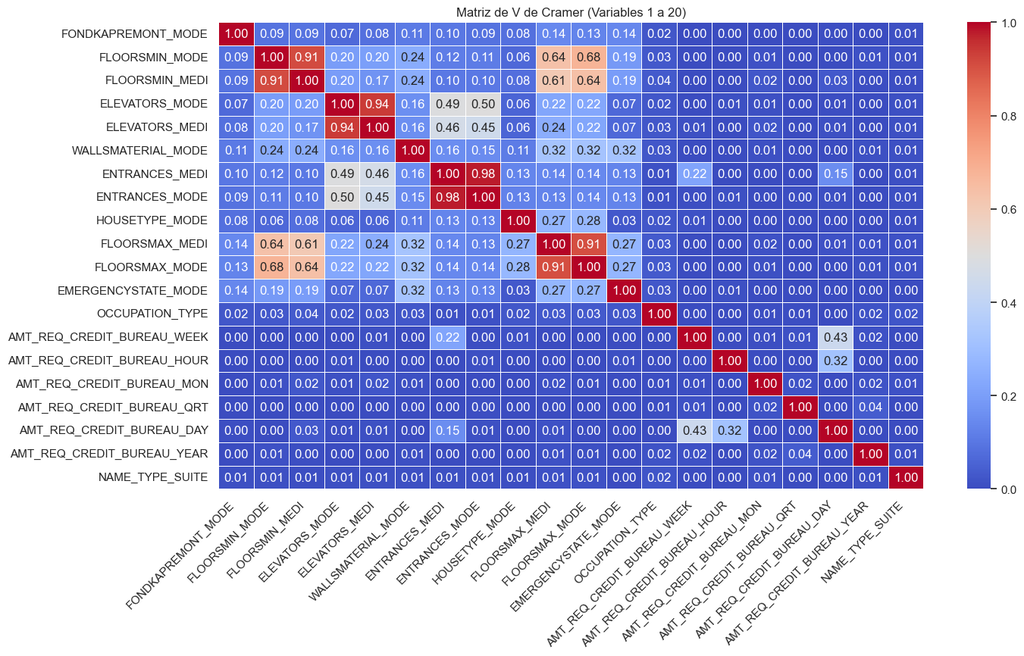

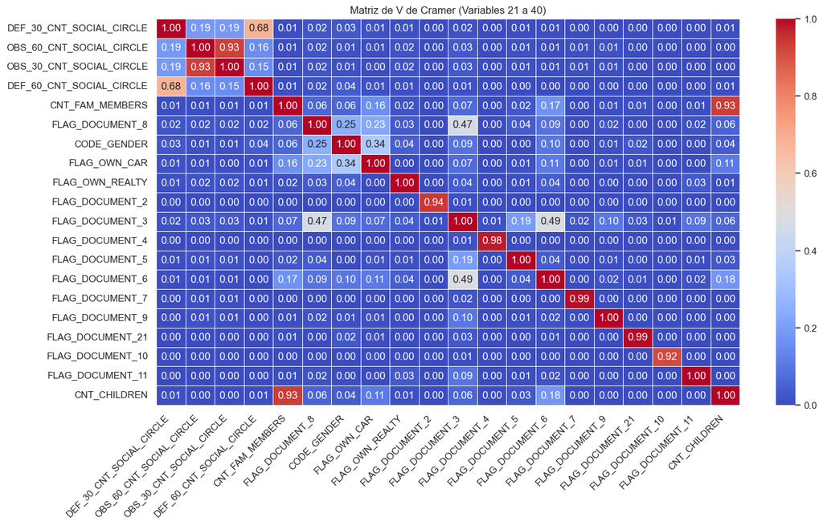

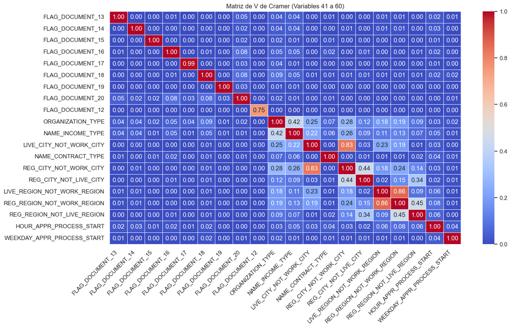

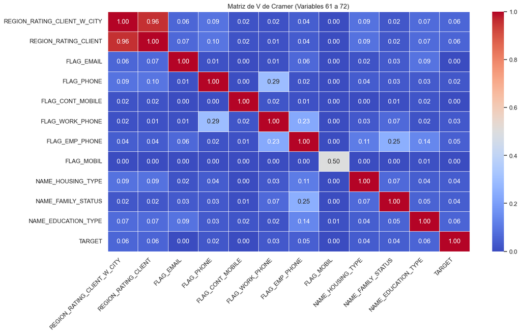

```python
# Al contar con muchas variables categoricas, se van a realizar submatrices para poder apreciar bien los datos, aunque perdamos la posibilidad de analizar algunas relaciones entre variables
variables_por_submatriz = 20
for i in range(0, len(list_var_cat), variables_por_submatriz):

    subset = list_var_cat[i:i + variables_por_submatriz]

    cramer_corr_subset = cramer_corr_matrix.loc[subset, subset]

    plt.figure(figsize=(15, 8))
    sns.heatmap(
        cramer_corr_subset,
        annot=True,
        cmap="coolwarm",
        fmt=".2f",
        linewidths=0.5
    )
    plt.title(f"Matriz de V de Cramer (Variables {i+1} a {i+len(subset)})")
    plt.xticks(rotation=45, ha='right')
    plt.yticks(rotation=0)
    plt.show()
```

Los valores más cercanos a 1 indican una alta asociación entre las variables categóricas, mientras que los valores cercanos a 0 sugieren poca o ninguna relación.

## **Tratamiento de valores nulos (variables categóricas)**

Decido sustituirlos por una nueva clase que voy a denominar "No disponible".

```python
pd_loan_train[list_var_cat] = pd_loan_train[list_var_cat].astype("object").fillna("No disponible").astype("category")
pd_loan_test[list_var_cat] = pd_loan_test[list_var_cat].astype("object").fillna("No disponible").astype("category")
```

[output not shown]

```python
pd_loan_train[list_var_cat]
```

|  | FONDKAPREMONT_MODE | FLOORSMIN_MODE | FLOORSMIN_MEDI | ELEVATORS_MODE | ELEVATORS_MEDI | WALLSMATERIAL_MODE | ENTRANCES_MEDI | ENTRANCES_MODE | HOUSETYPE_MODE | FLOORSMAX_MEDI | FLOORSMAX_MODE | EMERGENCYSTATE_MODE | OCCUPATION_TYPE | AMT_REQ_CREDIT_BUREAU_WEEK | AMT_REQ_CREDIT_BUREAU_HOUR | AMT_REQ_CREDIT_BUREAU_MON | AMT_REQ_CREDIT_BUREAU_QRT | AMT_REQ_CREDIT_BUREAU_DAY | AMT_REQ_CREDIT_BUREAU_YEAR | NAME_TYPE_SUITE | DEF_30_CNT_SOCIAL_CIRCLE | OBS_60_CNT_SOCIAL_CIRCLE | OBS_30_CNT_SOCIAL_CIRCLE | DEF_60_CNT_SOCIAL_CIRCLE | CNT_FAM_MEMBERS | FLAG_DOCUMENT_8 | CODE_GENDER | FLAG_OWN_CAR | FLAG_OWN_REALTY | … |
| --- | --- | --- | --- | --- | --- | --- | --- | --- | --- | --- | --- | --- | --- | --- | --- | --- | --- | --- | --- | --- | --- | --- | --- | --- | --- | --- | --- | --- | --- | --- |
| 236327 | reg oper account | 0.1667 | 0.1667 | 0.0 | 0.0 | Stone, brick | 0.069 | 0.069 | block of flats | 0.125 | 0.125 | No | No disponible | 0.0 | 0.0 | 1.0 | 0.0 | 0.0 | 0.0 | Unaccompanied | 0.0 | 0.0 | 0.0 | 0.0 | 1.0 | 0 | F | N | Y | … |
| 23526 | No disponible | No disponible | No disponible | No disponible | No disponible | No disponible | No disponible | No disponible | No disponible | No disponible | No disponible | No disponible | Managers | 0.0 | 0.0 | 3.0 | 0.0 | 0.0 | 0.0 | Unaccompanied | 1.0 | 2.0 | 2.0 | 0.0 | 2.0 | 0 | M | Y | N | … |
| 142647 | No disponible | No disponible | No disponible | No disponible | No disponible | No disponible | No disponible | No disponible | No disponible | No disponible | No disponible | No disponible | Cooking staff | 0.0 | 0.0 | 1.0 | 0.0 | 0.0 | 3.0 | Unaccompanied | 0.0 | 10.0 | 10.0 | 0.0 | 2.0 | 0 | F | N | Y | … |
| 294722 | No disponible | No disponible | No disponible | No disponible | No disponible | No disponible | No disponible | No disponible | No disponible | No disponible | No disponible | No | Sales staff | 0.0 | 0.0 | 0.0 | 0.0 | 0.0 | 1.0 | Unaccompanied | 0.0 | 5.0 | 5.0 | 0.0 | 3.0 | 0 | F | Y | Y | … |
| 119381 | No disponible | No disponible | No disponible | No disponible | No disponible | No disponible | No disponible | No disponible | No disponible | No disponible | No disponible | No disponible | Core staff | 0.0 | 0.0 | 0.0 | 1.0 | 0.0 | 3.0 | Spouse, partner | 0.0 | 0.0 | 0.0 | 0.0 | 3.0 | 0 | M | Y | N | … |
| ... | ... | ... | ... | ... | ... | ... | ... | ... | ... | ... | ... | ... | ... | ... | ... | ... | ... | ... | ... | ... | ... | ... | ... | ... | ... | ... | ... | ... | ... | … |
| 158780 | No disponible | No disponible | No disponible | No disponible | No disponible | No disponible | No disponible | No disponible | No disponible | No disponible | No disponible | No disponible | No disponible | No disponible | No disponible | No disponible | No disponible | No disponible | No disponible | Family | 0.0 | 0.0 | 0.0 | 0.0 | 2.0 | 0 | F | N | Y | … |
| 179956 | No disponible | No disponible | No disponible | No disponible | No disponible | No disponible | No disponible | No disponible | No disponible | No disponible | No disponible | No disponible | Cooking staff | No disponible | No disponible | No disponible | No disponible | No disponible | No disponible | Family | 0.0 | 17.0 | 17.0 | 0.0 | 2.0 | 0 | F | N | Y | … |
| 298923 | No disponible | No disponible | No disponible | 0.0 | 0.0 | Panel | 0.1034 | 0.1034 | block of flats | 0.1667 | 0.1667 | No | Cleaning staff | 0.0 | 0.0 | 0.0 | 0.0 | 0.0 | 2.0 | Unaccompanied | 0.0 | 1.0 | 1.0 | 0.0 | 3.0 | 0 | M | Y | Y | … |
| 43143 | reg oper account | 0.2083 | 0.2083 | 0.0 | 0.0 | Panel | 0.2069 | 0.2069 | block of flats | 0.1667 | 0.1667 | No | Drivers | 0.0 | 0.0 | 0.0 | 0.0 | 0.0 | 3.0 | Unaccompanied | 0.0 | 0.0 | 0.0 | 0.0 | 2.0 | 0 | M | Y | N | … |
| 43350 | No disponible | No disponible | No disponible | No disponible | No disponible | No disponible | No disponible | No disponible | No disponible | No disponible | No disponible | No disponible | Laborers | 0.0 | 0.0 | 0.0 | 0.0 | 0.0 | 2.0 | Unaccompanied | 0.0 | 3.0 | 3.0 | 0.0 | 2.0 | 0 | F | Y | Y | … |

246008 rows × 72 columns

# **Information value y WOE**

**Weight of Evidence (WOE)** nos indica el **poder de predicción de una variable independiente en relación a la variable dependiente**. Se suele usar mucho para problemas de crédito y scoring, usandose como medida para separar entre buenos y malos clientes. Malos clientes serían aquellos que no devuelven el préstamo mientras que los buenos sí lo devuelven. El WOE se calcula de la siguiente forma:

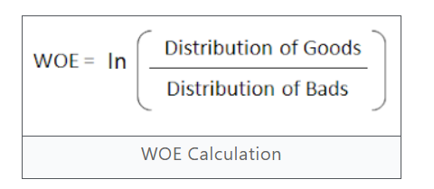

Donde: **'Distribution of Goods'** es el porcentaje de buenos clientes en el dataset y **'Diistribution of Bads'** el porcentaje de malos clientes.

El **Information value (IV)** es una métrica derivada del WOE. Se trata de una de las técnicas mas útiles para seleccionar importatnes variables en un modelo. Evalúa la capacidad predictiva de una variable independiente para distinguir entre dos clases de una variable objetivo. Se calcula con la siguiente fórmula:

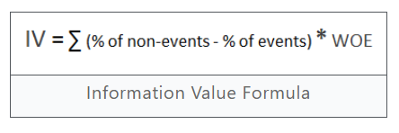

El IV clasifica el poder predictivo de una variable:

- IV < 0.02: sin valor predictivo.
- 0.02 ≤ IV < 0.1: poder predictivo débil.
- 0.1 ≤ IV < 0.3: poder predictivo medio.
- 0.3 ≤ IV < 0.5: poder predictivo fuerte.
- IV > 0.5: demasiado fuerte (posible sobreajuste o problema de multicolinealidad).

Fuente: https://www.listendata.com/2015/03/weight-of-evidence-woe-and-information.html#what_is_information_value

```python
help(f_aux.iv_woe) # Recordamos que parámetros hay que introducir en esta función.
```

```
Help on function iv_woe in module funciones_auxiliares:

iv_woe(df, variable, target, bins=None)
    Calcula el Weight of Evidence (WoE) y el Information Value (IV) para una variable respecto a una variable objetivo binaria.

    Parámetros:
    df (DataFrame): DataFrame que contiene los datos.
    variable (str): nombre de la variable para calcular WoE e IV.
    target (str): nombre de la variable objetivo (debe ser binaria).
    bins (int, optional): número de bins si la variable es continua y necesita binning.

    Retorna:
    tabla: DataFrame que contiene los valores de WoE e IV para cada categoría/bin de la variable.
    iv_total: Information Value (IV) total para la variable.
```

### IV y WOE para la variable *CODE_GENDER* frente a *TARGET*

```python
resultado_woe_iv, iv_total = f_aux.iv_woe(df = pd_loan, variable='CODE_GENDER' , target = 'TARGET')

print(resultado_woe_iv)
print('IV total es: ', iv_total)
```

```
  CODE_GENDER  buenos  malos  dist_buenos  dist_malos       WoE        IV
0           F  188278  14170     0.666032    0.570796  0.154307  0.014696
1           M   94404  10655     0.333954    0.429204 -0.250931  0.023901
2         XNA       4      0     0.000014    0.000000       NaN       NaN
IV total es:  0.038597117741972484
```

```
c:\Users\Jose Carlos\Desktop\CUNEF\MachineLearning\EDA JC\funciones_auxiliares.py:143: FutureWarning:

The default of observed=False is deprecated and will be changed to True in a future version of pandas. Pass observed=False to retain current behavior or observed=True to adopt the future default and silence this warning.
```

**El IV total es de 0.038** por lo que la variable 'CODE_GENDER' tiene un **valor predictivo débil**. No es relevante para el modelo, pero podría usarse conjuntamente a otras variables.

### IV y WOE para la variable *NAME_INCOME_TYPE* frente a *TARGET*

```python
resultado_woe_iv, iv_total = f_aux.iv_woe(df = pd_loan, variable='NAME_INCOME_TYPE' , target = 'TARGET')

print(resultado_woe_iv)
print('IV total es: ', iv_total)
```

```
       NAME_INCOME_TYPE  buenos  malos  dist_buenos  dist_malos       WoE  \
0           Businessman      10      0     0.000035    0.000000       NaN
1  Commercial associate   66257   5360     0.234384    0.215911  0.082092
2       Maternity leave       3      2     0.000011    0.000081 -2.027020
3             Pensioner   52380   2982     0.185294    0.120121  0.433445
4         State servant   20454   1249     0.072356    0.050312  0.363350
5               Student      18      0     0.000064    0.000000       NaN
6            Unemployed      14      8     0.000050    0.000322 -1.872870
7               Working  143550  15224     0.507807    0.613253 -0.188675

         IV
0       NaN
1  0.001516
2  0.000142
3  0.028249
4  0.008010
5       NaN
6  0.000511
7  0.019895
IV total es:  0.05832249890820593
```

```
c:\Users\Jose Carlos\Desktop\CUNEF\MachineLearning\EDA JC\funciones_auxiliares.py:143: FutureWarning:

The default of observed=False is deprecated and will be changed to True in a future version of pandas. Pass observed=False to retain current behavior or observed=True to adopt the future default and silence this warning.
```

Maternity leave y Unemployed muestran valores negativos (-2.02 y -1.87), esto indica una fuerte relación negativa con 'TARGET'. Pensioner y State servant tienen valores positivos mostrando una relación positiva.

**El IV total es de 0.058**, valor muy bajo por lo que esta variable también tiene poca capacidad predictiva.

# **Guardado de tabla**

```python
print(pd_loan_train.shape, pd_loan_test.shape)
```

```
(246008, 122) (61503, 122)
```

```python
pd_loan_train.to_csv("./train_pd_data_preprocessing_missing_outlier.csv")
pd_loan_test.to_csv("./test_pd_data_preprocessing_missing_outlier.csv")
```